# ANCOVA in Reading Comprehension (Reading Comprehension)

Geiser C. Challco geiser@alumni.usp.br

- Setting Initial Variables
- Descriptive Statistics of Initial Data
- ANCOVA and Pairwise for one factor: **grupo**
  - Without remove non-normal data
  - Computing ANCOVA and PairWise After removing non-normal data (OK)
    - Plots for ancova
    - Checking linearity assumption
    - Checking normality and homogeneity
- ANCOVA and Pairwise for two factors **grupo:genero**
  - Without remove non-normal data
  - Computing ANCOVA and PairWise After removing non-normal data (OK)
    - Plots for ancova
    - Checking linearity assumption
    - Checking normality and homogeneity
- ANCOVA and Pairwise for two factors **grupo:zona.participante**
  - Without remove non-normal data
  - Computing ANCOVA and PairWise After removing non-normal data (OK)
    - Plots for ancova
    - Checking linearity assumption
    - Checking normality and homogeneity
- ANCOVA and Pairwise for two factors **grupo:zona.escola**
  - Without remove non-normal data
  - Computing ANCOVA and PairWise After removing non-normal data (OK)
    - Plots for ancova
    - Checking linearity assumption
    - Checking normality and homogeneity
- ANCOVA and Pairwise for two factors **grupo:score.compreensao.quintile**
  - Without remove non-normal data
  - Computing ANCOVA and PairWise After removing non-normal data (OK)
    - Plots for ancova
    - Checking linearity assumption
    - Checking normality and homogeneity
- Summary of Results
  - Descriptive Statistics
  - ANCOVA Table Comparison
  - PairWise Table Comparison
  - EMMS Table Comparison

**NOTE**:

- Teste ANCOVA para determinar se houve diferenças significativas no Reading Comprehension (medido usando pre- e pos-testes).
- ANCOVA test to determine whether there were significant differences in Reading Comprehension (measured using pre- and post-tests).

# Setting Initial Variables

```r
dv = "score.compreensao"
dv.pos = "score.compreensao.pos"
dv.pre = "score.compreensao.pre"

fatores2 <- c("genero","zona.participante","zona.escola","score.compreensao.quintile")
lfatores2 <- as.list(fatores2)
names(lfatores2) <- fatores2

fatores1 <- c("grupo", fatores2)
lfatores1 <- as.list(fatores1)
names(lfatores1) <- fatores1

lfatores <- c(lfatores1)

color <- list()
color[["prepost"]] = c("#ffee65","#f28e2B")
color[["grupo"]] = c("#bcbd22","#fd7f6f")
color[["genero"]] = c("#FF007F","#4D4DFF")
color[["zona.escola"]] = c("#AA00FF","#00CCCC")
color[["zona.participante"]] = c("#AA00FF","#00CCCC")

level <- list()
level[["grupo"]] = c("Controle","Experimental")
level[["genero"]] = c("F","M")
level[["zona.escola"]] = c("Rural","Urbana")
level[["zona.participante"]] = c("Rural","Urbana")

# ..

ymin <- 0
ymax <- 0

ymin.ci <- 0
ymax.ci <- 0


color[["grupo:genero"]] = c(
  "Controle:F"="#ff99cb", "Controle:M"="#b7b7ff",
  "Experimental:F"="#FF007F", "Experimental:M"="#4D4DFF",
  "Controle.F"="#ff99cb", "Controle.M"="#b7b7ff",
  "Experimental.F"="#FF007F", "Experimental.M"="#4D4DFF"
)
color[["grupo:zona.escola"]] = c(
  "Controle:Rural"="#b2efef","Controle:Urbana"="#e5b2ff",
  "Experimental:Rural"="#00CCCC", "Experimental:Urbana"="#AA00FF",
  "Controle.Rural"="#b2efef","Controle.Urbana"="#e5b2ff",
  "Experimental.Rural"="#00CCCC", "Experimental.Urbana"="#AA00FF"
)
color[["grupo:zona.participante"]] = c(
  "Controle:Rural"="#b2efef","Controle:Urbana"="#e5b2ff",
  "Experimental:Rural"="#00CCCC", "Experimental:Urbana"="#AA00FF",
  "Controle.Rural"="#b2efef","Controle.Urbana"="#e5b2ff",
  "Experimental.Rural"="#00CCCC", "Experimental.Urbana"="#AA00FF"
)

for (coln in c(
  "palavras.lidas","score.compreensao","tri.compreensao",
  "score.vocab","tri.vocab",
  "score.vocab.ensinado","tri.vocab.ensinado","score.vocab.nao.ensinado","tri.vocab.nao.ensinado",
  "score.CLPP","tri.CLPP","score.CR","tri.CR",
  "score.CI","tri.CI","score.TV","tri.TV","score.TF","tri.TF","score.TO","tri.TO")) {
  color[[paste0(coln,".quintile")]] = c("#BF0040","#FF0000","#800080","#0000FF","#4000BF")
  level[[paste0(coln,".quintile")]] = c("1st quintile","2nd quintile","3rd quintile","4th quintile","5th quintile")
  color[[paste0("grupo:",coln,".quintile")]] = c(
    "Experimental.1st quintile"="#BF0040", "Controle.1st quintile"="#d8668c",
    "Experimental.2nd quintile"="#FF0000", "Controle.2nd quintile"="#ff7f7f",
    "Experimental.3rd quintile"="#8fce00", "Controle.3rd quintile"="#ddf0b2",
    "Experimental.4th quintile"="#0000FF", "Controle.4th quintile"="#b2b2ff",
    "Experimental.5th quintile"="#4000BF", "Controle.5th quintile"="#b299e5",

    "Experimental:1st quintile"="#BF0040", "Controle:1st quintile"="#d8668c",
    "Experimental:2nd quintile"="#FF0000", "Controle:2nd quintile"="#ff7f7f",
    "Experimental:3rd quintile"="#8fce00", "Controle:3rd quintile"="#ddf0b2",
    "Experimental:4th quintile"="#0000FF", "Controle:4th quintile"="#b2b2ff",
    "Experimental:5th quintile"="#4000BF", "Controle:5th quintile"="#b299e5")
}


gdat <- read_excel("../data/data.xlsx", sheet = "triagem.st")



dat <- gdat
dat$grupo <- factor(dat[["grupo"]], level[["grupo"]])
for (coln in c(names(lfatores))) {
  dat[[coln]] <- factor(dat[[coln]], level[[coln]][level[[coln]] %in% unique(dat[[coln]])])
}
dat <- dat[which(!is.na(dat[[dv.pre]]) & !is.na(dat[[dv.pos]])),]
dat <- dat[,c("id",names(lfatores),dv.pre,dv.pos)]

dat.long <- rbind(dat, dat)
dat.long$time <- c(rep("pre", nrow(dat)), rep("pos", nrow(dat)))
dat.long$time <- factor(dat.long$time, c("pre","pos"))
dat.long[[dv]] <- c(dat[[dv.pre]], dat[[dv.pos]])


for (f in c("grupo", names(lfatores))) {
  if (is.null(color[[f]]) && length(unique(dat[[f]])) > 0)
      color[[f]] <- distinctColorPalette(length(unique(dat[[f]])))
}
for (f in c(fatores2)) {
  if (is.null(color[[paste0("grupo:",f)]]) && length(unique(dat[[f]])) > 0)
    color[[paste0("grupo:",f)]] <- distinctColorPalette(length(unique(dat[["grupo"]]))*length(unique(dat[[f]])))
}

ldat <- list()
laov <- list()
lpwc <- list()
lemms <- list()
```

# Descriptive Statistics of Initial Data

```r
df <- get.descriptives(dat, c(dv.pre, dv.pos), c("grupo"),
                       include.global = T, symmetry.test = T, normality.test = F)
df <- plyr::rbind.fill(
  df, do.call(plyr::rbind.fill, lapply(lfatores2, FUN = function(f) {
    if (nrow(dat) > 0 && sum(!is.na(unique(dat[[f]]))) > 1)
      get.descriptives(dat, c(dv.pre,dv.pos), c("grupo", f),
                       symmetry.test = T, normality.test = F)
    }))
)
df <- df[,c(fatores1[fatores1 %in% colnames(df)],"variable",
            colnames(df)[!colnames(df) %in% c(fatores1,"variable")])]
```

| grupo | genero | zona.participante | zona.escola | score.compreensao.quintile | variable | n | mean | median | min | max | sd | se | ci | iqr | symmetry | skewness | kurtosis |
| --- | --- | --- | --- | --- | --- | --- | --- | --- | --- | --- | --- | --- | --- | --- | --- | --- | --- |
| Controle |  |  |  |  | score.compreensao.pre | 45 | 3.378 | 3.0 | 0 | 9 | 1.527 | 0.228 | 0.459 | 2.00 | NO | 0.864 | 2.410 |
| Experimental |  |  |  |  | score.compreensao.pre | 37 | 2.865 | 2.0 | 0 | 6 | 1.619 | 0.266 | 0.540 | 1.00 | NO | 0.633 | -0.613 |
|  |  |  |  |  | score.compreensao.pre | 82 | 3.146 | 3.0 | 0 | 9 | 1.580 | 0.174 | 0.347 | 2.00 | NO | 0.708 | 0.959 |
| Controle |  |  |  |  | score.compreensao.pos | 45 | 3.511 | 3.0 | 0 | 9 | 1.792 | 0.267 | 0.538 | 2.00 | NO | 0.573 | 0.436 |
| Experimental |  |  |  |  | score.compreensao.pos | 37 | 3.189 | 3.0 | 1 | 9 | 1.745 | 0.287 | 0.582 | 2.00 | NO | 0.938 | 1.321 |
|  |  |  |  |  | score.compreensao.pos | 82 | 3.366 | 3.0 | 0 | 9 | 1.767 | 0.195 | 0.388 | 2.00 | NO | 0.743 | 0.838 |
| Controle | F |  |  |  | score.compreensao.pre | 24 | 3.458 | 3.0 | 0 | 9 | 1.744 | 0.356 | 0.736 | 1.25 | NO | 0.915 | 2.243 |
| Controle | M |  |  |  | score.compreensao.pre | 21 | 3.286 | 3.0 | 1 | 6 | 1.271 | 0.277 | 0.578 | 2.00 | YES | 0.321 | -0.766 |
| Experimental | F |  |  |  | score.compreensao.pre | 18 | 2.833 | 2.0 | 1 | 6 | 1.543 | 0.364 | 0.768 | 1.00 | NO | 1.078 | -0.437 |
| Experimental | M |  |  |  | score.compreensao.pre | 19 | 2.895 | 3.0 | 0 | 6 | 1.729 | 0.397 | 0.833 | 2.00 | YES | 0.275 | -0.938 |
| Controle | F |  |  |  | score.compreensao.pos | 24 | 4.208 | 4.0 | 2 | 9 | 1.793 | 0.366 | 0.757 | 2.00 | NO | 0.654 | 0.015 |
| Controle | M |  |  |  | score.compreensao.pos | 21 | 2.714 | 3.0 | 0 | 6 | 1.454 | 0.317 | 0.662 | 2.00 | YES | 0.104 | -0.626 |
| Experimental | F |  |  |  | score.compreensao.pos | 18 | 3.667 | 3.0 | 1 | 9 | 1.782 | 0.420 | 0.886 | 1.00 | NO | 1.361 | 2.025 |
| Experimental | M |  |  |  | score.compreensao.pos | 19 | 2.737 | 2.0 | 1 | 6 | 1.628 | 0.373 | 0.784 | 3.00 | YES | 0.403 | -1.261 |
| Controle |  | Rural |  |  | score.compreensao.pre | 12 | 3.417 | 3.5 | 2 | 5 | 0.900 | 0.260 | 0.572 | 1.00 | YES | -0.116 | -1.093 |
| Controle |  | Urbana |  |  | score.compreensao.pre | 23 | 3.696 | 3.0 | 1 | 9 | 1.743 | 0.364 | 0.754 | 2.50 | NO | 1.040 | 1.376 |
| Controle |  |  |  |  | score.compreensao.pre | 10 | 2.600 | 3.0 | 0 | 5 | 1.430 | 0.452 | 1.023 | 1.00 | YES | -0.181 | -0.856 |
| Experimental |  | Rural |  |  | score.compreensao.pre | 15 | 3.267 | 3.0 | 1 | 6 | 1.831 | 0.473 | 1.014 | 3.00 | YES | 0.415 | -1.510 |
| Experimental |  | Urbana |  |  | score.compreensao.pre | 12 | 2.167 | 2.0 | 0 | 6 | 1.467 | 0.423 | 0.932 | 0.50 | NO | 1.165 | 1.368 |
| Experimental |  |  |  |  | score.compreensao.pre | 10 | 3.100 | 3.0 | 1 | 5 | 1.287 | 0.407 | 0.920 | 1.50 | YES | 0.118 | -1.209 |
| Controle |  | Rural |  |  | score.compreensao.pos | 12 | 3.667 | 4.0 | 2 | 5 | 0.985 | 0.284 | 0.626 | 1.00 | YES | -0.427 | -1.031 |
| Controle |  | Urbana |  |  | score.compreensao.pos | 23 | 4.000 | 4.0 | 1 | 9 | 2.067 | 0.431 | 0.894 | 3.50 | YES | 0.443 | -0.576 |
| Controle |  |  |  |  | score.compreensao.pos | 10 | 2.200 | 2.5 | 0 | 4 | 1.229 | 0.389 | 0.879 | 1.75 | YES | -0.336 | -1.261 |
| Experimental |  | Rural |  |  | score.compreensao.pos | 15 | 3.533 | 3.0 | 1 | 9 | 1.995 | 0.515 | 1.105 | 2.00 | NO | 1.264 | 1.200 |
| Experimental |  | Urbana |  |  | score.compreensao.pos | 12 | 2.917 | 3.0 | 1 | 5 | 1.443 | 0.417 | 0.917 | 2.25 | YES | -0.035 | -1.433 |
| Experimental |  |  |  |  | score.compreensao.pos | 10 | 3.000 | 3.0 | 1 | 6 | 1.764 | 0.558 | 1.262 | 2.75 | YES | 0.219 | -1.471 |
| Controle |  |  | Rural |  | score.compreensao.pre | 13 | 4.000 | 4.0 | 1 | 9 | 1.826 | 0.506 | 1.103 | 1.00 | NO | 1.213 | 1.929 |
| Controle |  |  | Urbana |  | score.compreensao.pre | 32 | 3.125 | 3.0 | 0 | 6 | 1.338 | 0.237 | 0.482 | 2.00 | YES | 0.093 | -0.434 |
| Experimental |  |  | Rural |  | score.compreensao.pre | 12 | 3.000 | 3.0 | 1 | 6 | 1.414 | 0.408 | 0.899 | 1.25 | NO | 0.707 | -0.542 |
| Experimental |  |  | Urbana |  | score.compreensao.pre | 25 | 2.800 | 2.0 | 0 | 6 | 1.732 | 0.346 | 0.715 | 1.00 | NO | 0.619 | -0.813 |
| Controle |  |  | Rural |  | score.compreensao.pos | 13 | 3.923 | 4.0 | 1 | 7 | 1.605 | 0.445 | 0.970 | 2.00 | YES | 0.114 | -0.686 |
| Controle |  |  | Urbana |  | score.compreensao.pos | 32 | 3.344 | 3.0 | 0 | 9 | 1.860 | 0.329 | 0.671 | 2.00 | NO | 0.763 | 0.758 |
| Experimental |  |  | Rural |  | score.compreensao.pos | 12 | 3.417 | 3.5 | 1 | 6 | 1.379 | 0.398 | 0.876 | 1.25 | YES | 0.063 | -0.844 |
| Experimental |  |  | Urbana |  | score.compreensao.pos | 25 | 3.080 | 3.0 | 1 | 9 | 1.913 | 0.383 | 0.790 | 2.00 | NO | 1.125 | 1.364 |
| Controle |  |  |  | 1st quintile | score.compreensao.pre | 3 | 0.667 | 1.0 | 0 | 1 | 0.577 | 0.333 | 1.434 | 0.50 | few data | 0.000 | 0.000 |
| Controle |  |  |  | 2nd quintile | score.compreensao.pre | 23 | 2.609 | 3.0 | 2 | 3 | 0.499 | 0.104 | 0.216 | 1.00 | few data | 0.000 | 0.000 |
| Controle |  |  |  | 3rd quintile | score.compreensao.pre | 18 | 4.500 | 4.0 | 4 | 6 | 0.618 | 0.146 | 0.307 | 1.00 | few data | 0.000 | 0.000 |
| Controle |  |  |  | 5th quintile | score.compreensao.pre | 1 | 9.000 | 9.0 | 9 | 9 |  |  |  | 0.00 | few data | 0.000 | 0.000 |
| Experimental |  |  |  | 1st quintile | score.compreensao.pre | 6 | 0.833 | 1.0 | 0 | 1 | 0.408 | 0.167 | 0.428 | 0.00 | few data | 0.000 | 0.000 |
| Experimental |  |  |  | 2nd quintile | score.compreensao.pre | 22 | 2.409 | 2.0 | 2 | 3 | 0.503 | 0.107 | 0.223 | 1.00 | few data | 0.000 | 0.000 |
| Experimental |  |  |  | 3rd quintile | score.compreensao.pre | 9 | 5.333 | 5.0 | 4 | 6 | 0.707 | 0.236 | 0.544 | 1.00 | few data | 0.000 | 0.000 |
| Controle |  |  |  | 1st quintile | score.compreensao.pos | 3 | 3.000 | 3.0 | 2 | 4 | 1.000 | 0.577 | 2.484 | 1.00 | few data | 0.000 | 0.000 |
| Controle |  |  |  | 2nd quintile | score.compreensao.pos | 23 | 3.087 | 3.0 | 0 | 6 | 1.676 | 0.350 | 0.725 | 2.00 | YES | 0.202 | -0.866 |
| Controle |  |  |  | 3rd quintile | score.compreensao.pos | 18 | 3.944 | 4.0 | 1 | 9 | 1.830 | 0.431 | 0.910 | 2.00 | NO | 0.838 | 0.944 |
| Controle |  |  |  | 5th quintile | score.compreensao.pos | 1 | 7.000 | 7.0 | 7 | 7 |  |  |  | 0.00 | few data | 0.000 | 0.000 |
| Experimental |  |  |  | 1st quintile | score.compreensao.pos | 6 | 2.167 | 2.0 | 1 | 3 | 0.753 | 0.307 | 0.790 | 0.75 | few data | 0.000 | 0.000 |
| Experimental |  |  |  | 2nd quintile | score.compreensao.pos | 22 | 3.227 | 3.0 | 1 | 9 | 1.926 | 0.411 | 0.854 | 2.00 | NO | 1.067 | 1.359 |
| Experimental |  |  |  | 3rd quintile | score.compreensao.pos | 9 | 3.778 | 4.0 | 1 | 6 | 1.563 | 0.521 | 1.202 | 2.00 | YES | -0.374 | -1.164 |

# ANCOVA and Pairwise for one factor: **grupo**

## Without remove non-normal data

```r
pdat = remove_group_data(dat[!is.na(dat[["grupo"]]),], "score.compreensao.pos", "grupo")

pdat.long <- rbind(pdat[,c("id","grupo")], pdat[,c("id","grupo")])
pdat.long[["time"]] <- c(rep("pre", nrow(pdat)), rep("pos", nrow(pdat)))
pdat.long[["time"]] <- factor(pdat.long[["time"]], c("pre","pos"))
pdat.long[["score.compreensao"]] <- c(pdat[["score.compreensao.pre"]], pdat[["score.compreensao.pos"]])

aov = anova_test(pdat, score.compreensao.pos ~ score.compreensao.pre + grupo)
laov[["grupo"]] <- get_anova_table(aov)
```

```r
pwc <- emmeans_test(pdat, score.compreensao.pos ~ grupo, covariate = score.compreensao.pre,
                    p.adjust.method = "bonferroni")
```

```r
pwc.long <- emmeans_test(dplyr::group_by_at(pdat.long, "grupo"),
                          score.compreensao ~ time,
                          p.adjust.method = "bonferroni")
lpwc[["grupo"]] <- plyr::rbind.fill(pwc, pwc.long)
```

```r
ds <- get.descriptives(pdat, "score.compreensao.pos", "grupo", covar = "score.compreensao.pre")
ds <- merge(ds[ds$variable != "score.compreensao.pre",],
            ds[ds$variable == "score.compreensao.pre", !colnames(ds) %in% c("variable")],
            by = "grupo", all.x = T, suffixes = c("", ".score.compreensao.pre"))
ds <- merge(get_emmeans(pwc), ds, by = "grupo", suffixes = c(".emms", ""))
ds <- ds[,c("grupo","n","mean.score.compreensao.pre","se.score.compreensao.pre","mean","se",
            "emmean","se.emms","conf.low","conf.high")]

colnames(ds) <- c("grupo", "N", paste0(c("M","SE")," (pre)"),
                  paste0(c("M","SE"), " (unadj)"),
                  paste0(c("M", "SE"), " (adj)"), "conf.low", "conf.high")

lemms[["grupo"]] <- ds
```

## Computing ANCOVA and PairWise After removing non-normal data (OK)

```r
wdat = pdat

res = residuals(lm(score.compreensao.pos ~ score.compreensao.pre + grupo, data = wdat))
non.normal = getNonNormal(res, wdat$id, plimit = 0.05)

wdat = wdat[!wdat$id %in% non.normal,]

wdat.long <- rbind(wdat[,c("id","grupo")], wdat[,c("id","grupo")])
wdat.long[["time"]] <- c(rep("pre", nrow(wdat)), rep("pos", nrow(wdat)))
wdat.long[["time"]] <- factor(wdat.long[["time"]], c("pre","pos"))
wdat.long[["score.compreensao"]] <- c(wdat[["score.compreensao.pre"]], wdat[["score.compreensao.pos"]])

ldat[["grupo"]] = wdat

(non.normal)
```

```
## [1] "P270"
```

```r
aov = anova_test(wdat, score.compreensao.pos ~ score.compreensao.pre + grupo)
laov[["grupo"]] <- merge(get_anova_table(aov), laov[["grupo"]],
                            by="Effect", suffixes = c("","'"))

(df = get_anova_table(aov))
```

```
## ANOVA Table (type II tests)
##
##                  Effect DFn DFd      F     p p<.05   ges
## 1 score.compreensao.pre   1  78 10.330 0.002     * 0.117
## 2                 grupo   1  78  0.756 0.387       0.010
```

| Effect | DFn | DFd | F | p | p<.05 | ges |
| --- | --- | --- | --- | --- | --- | --- |
| score.compreensao.pre | 1 | 78 | 10.330 | 0.002 | * | 0.117 |
| grupo | 1 | 78 | 0.756 | 0.387 |  | 0.010 |

```r
pwc <- emmeans_test(wdat, score.compreensao.pos ~ grupo, covariate = score.compreensao.pre,
                    p.adjust.method = "bonferroni")
```

| term | .y. | group1 | group2 | df | statistic | p | p.adj | p.adj.signif |
| --- | --- | --- | --- | --- | --- | --- | --- | --- |
| score.compreensao.pre*grupo | score.compreensao.pos | Controle | Experimental | 78 | 0.869 | 0.387 | 0.387 | ns |

```r
pwc.long <- emmeans_test(dplyr::group_by_at(wdat.long, "grupo"),
                         score.compreensao ~ time,
                         p.adjust.method = "bonferroni")
lpwc[["grupo"]] <- merge(plyr::rbind.fill(pwc, pwc.long), lpwc[["grupo"]],
                            by=c("grupo","term",".y.","group1","group2"),
                            suffixes = c("","'"))
```

| grupo | term | .y. | group1 | group2 | df | statistic | p | p.adj | p.adj.signif |
| --- | --- | --- | --- | --- | --- | --- | --- | --- | --- |
| Controle | time | score.compreensao | pre | pos | 158 | -0.391 | 0.696 | 0.696 | ns |
| Experimental | time | score.compreensao | pre | pos | 158 | -0.365 | 0.716 | 0.716 | ns |

```r
ds <- get.descriptives(wdat, "score.compreensao.pos", "grupo", covar = "score.compreensao.pre")
ds <- merge(ds[ds$variable != "score.compreensao.pre",],
            ds[ds$variable == "score.compreensao.pre", !colnames(ds) %in% c("variable")],
            by = "grupo", all.x = T, suffixes = c("", ".score.compreensao.pre"))
ds <- merge(get_emmeans(pwc), ds, by = "grupo", suffixes = c(".emms", ""))
ds <- ds[,c("grupo","n","mean.score.compreensao.pre","se.score.compreensao.pre","mean","se",
            "emmean","se.emms","conf.low","conf.high")]

colnames(ds) <- c("grupo", "N", paste0(c("M","SE")," (pre)"),
                  paste0(c("M","SE"), " (unadj)"),
                  paste0(c("M", "SE"), " (adj)"), "conf.low", "conf.high")

lemms[["grupo"]] <- merge(ds, lemms[["grupo"]], by=c("grupo"), suffixes = c("","'"))
```

| grupo | N | M (pre) | SE (pre) | M (unadj) | SE (unadj) | M (adj) | SE (adj) | conf.low | conf.high |
| --- | --- | --- | --- | --- | --- | --- | --- | --- | --- |
| Controle | 45 | 3.378 | 0.228 | 3.511 | 0.267 | 3.433 | 0.234 | 2.966 | 3.900 |
| Experimental | 36 | 2.889 | 0.272 | 3.028 | 0.244 | 3.125 | 0.263 | 2.603 | 3.648 |

### Plots for ancova

```r
plots <- oneWayAncovaPlots(
  wdat, "score.compreensao.pos", "grupo", aov, list("grupo"=pwc), addParam = c("mean_ci"),
  font.label.size=10, step.increase=0.05, p.label="p.adj",
  subtitle = which(aov$Effect == "grupo"))
```

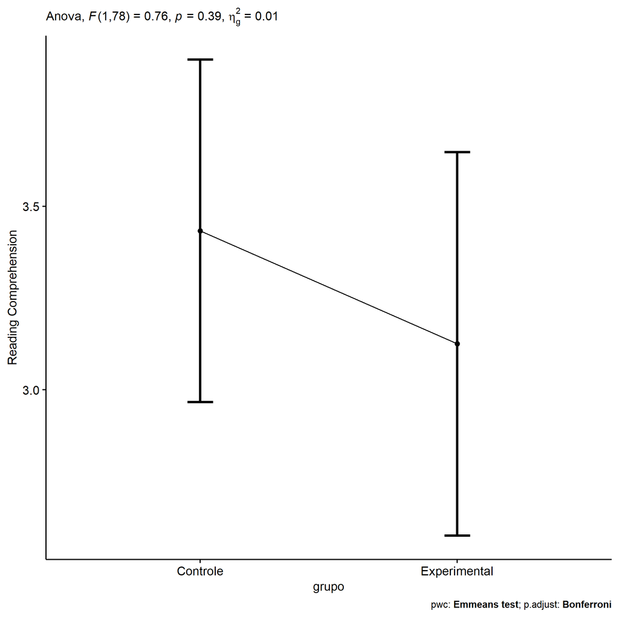

```r
if (!is.null(nrow(plots[["grupo"]]$data)))
  plots[["grupo"]] + ggplot2::ylab("Reading Comprehension") +
  if (ymin.ci < ymax.ci) ggplot2::ylim(ymin.ci, ymax.ci)
```

```r
plots <- oneWayAncovaBoxPlots(
  wdat, "score.compreensao.pos", "grupo", aov, pwc, covar = "score.compreensao.pre",
  theme = "classic", color = color[["grupo"]],
  subtitle = which(aov$Effect == "grupo"))
```

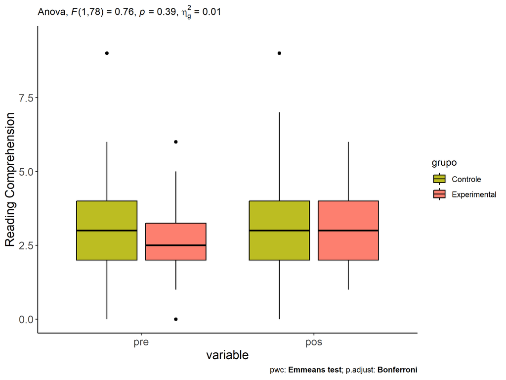

```r
if (length(unique(wdat[["grupo"]])) > 1)
  plots[["grupo"]] + ggplot2::ylab("Reading Comprehension") +
  ggplot2::scale_x_discrete(labels=c('pre', 'pos')) +
  if (ymin < ymax) ggplot2::ylim(ymin, ymax)
```

```r
if (length(unique(wdat.long[["grupo"]])) > 1)
  plots <- oneWayAncovaBoxPlots(
    wdat.long, "score.compreensao", "grupo", aov, pwc.long,
    pre.post = "time", theme = "classic", color = color$prepost)
```

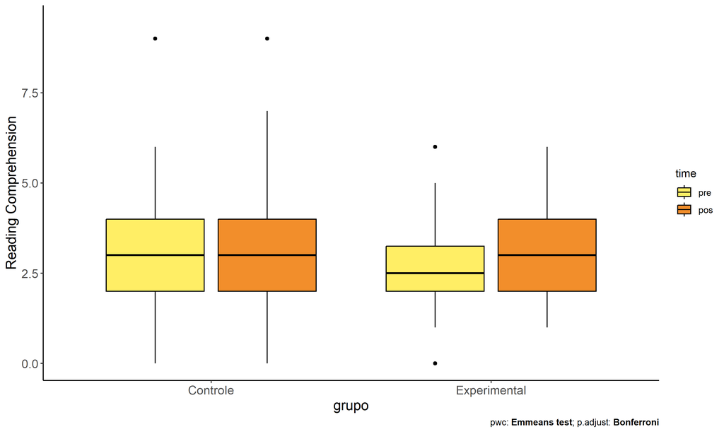

```r
if (length(unique(wdat.long[["grupo"]])) > 1)
  plots[["grupo"]] + ggplot2::ylab("Reading Comprehension") +
  if (ymin < ymax) ggplot2::ylim(ymin, ymax)
```

### Checking linearity assumption

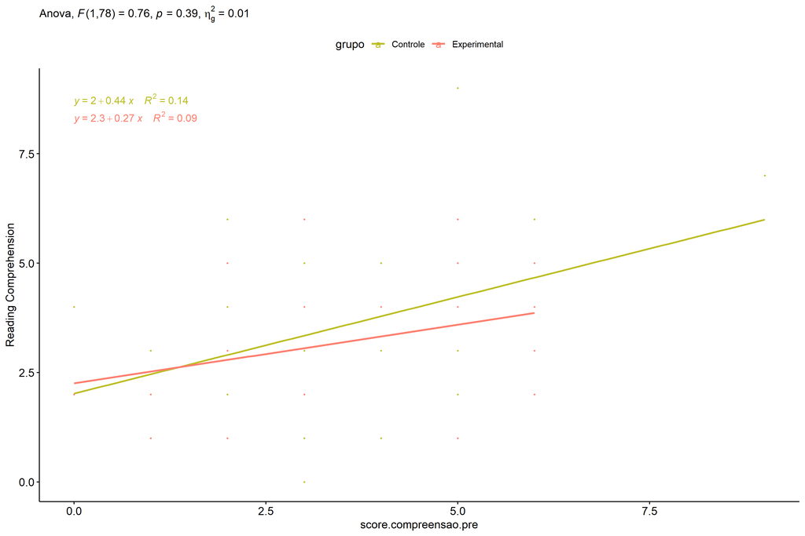

```r
ggscatter(wdat, x = "score.compreensao.pre", y = "score.compreensao.pos", size = 0.5,
          color = "grupo", add = "reg.line")+
  stat_regline_equation(
    aes(label =  paste(..eq.label.., ..rr.label.., sep = "~~~~"), color = grupo)
  ) +
  ggplot2::labs(subtitle = rstatix::get_test_label(aov, detailed = T, row = which(aov$Effect == "grupo"))) +
  ggplot2::scale_color_manual(values = color[["grupo"]]) +
  ggplot2::ylab("Reading Comprehension")  +
  if (ymin < ymax) ggplot2::ylim(ymin, ymax)
```

### Checking normality and homogeneity

```r
res <- augment(lm(score.compreensao.pos ~ score.compreensao.pre + grupo, data = wdat))
```

```r
shapiro_test(res$.resid)
```

```
## # A tibble: 1 × 3
##   variable   statistic p.value
##   <chr>          <dbl>   <dbl>
## 1 res$.resid     0.980   0.237
```

```r
levene_test(res, .resid ~ grupo)
```

```
## # A tibble: 1 × 4
##     df1   df2 statistic     p
##   <int> <int>     <dbl> <dbl>
## 1     1    79      1.04 0.310
```

# ANCOVA and Pairwise for two factors **grupo:genero**

## Without remove non-normal data

```r
pdat = remove_group_data(dat[!is.na(dat[["grupo"]]) & !is.na(dat[["genero"]]),],
                         "score.compreensao.pos", c("grupo","genero"))
pdat = pdat[pdat[["genero"]] %in% do.call(
  intersect, lapply(unique(pdat[["grupo"]]), FUN = function(x) {
    unique(pdat[["genero"]][which(pdat[["grupo"]] == x)])
  })),]
pdat[["grupo"]] = factor(pdat[["grupo"]], level[["grupo"]])
pdat[["genero"]] = factor(
  pdat[["genero"]],
  level[["genero"]][level[["genero"]] %in% unique(pdat[["genero"]])])

pdat.long <- rbind(pdat[,c("id","grupo","genero")], pdat[,c("id","grupo","genero")])
pdat.long[["time"]] <- c(rep("pre", nrow(pdat)), rep("pos", nrow(pdat)))
pdat.long[["time"]] <- factor(pdat.long[["time"]], c("pre","pos"))
pdat.long[["score.compreensao"]] <- c(pdat[["score.compreensao.pre"]], pdat[["score.compreensao.pos"]])

if (length(unique(pdat[["genero"]])) >= 2) {
  aov = anova_test(pdat, score.compreensao.pos ~ score.compreensao.pre + grupo*genero)
  laov[["grupo:genero"]] <- get_anova_table(aov)
}
```

```r
if (length(unique(pdat[["genero"]])) >= 2) {
  pwcs <- list()
  pwcs[["genero"]] <- emmeans_test(
    group_by(pdat, grupo), score.compreensao.pos ~ genero,
    covariate = score.compreensao.pre, p.adjust.method = "bonferroni")
  pwcs[["grupo"]] <- emmeans_test(
    group_by(pdat, genero), score.compreensao.pos ~ grupo,
    covariate = score.compreensao.pre, p.adjust.method = "bonferroni")

  pwc <- plyr::rbind.fill(pwcs[["grupo"]], pwcs[["genero"]])
  pwc <- pwc[,c("grupo","genero", colnames(pwc)[!colnames(pwc) %in% c("grupo","genero")])]
}
```

```r
if (length(unique(pdat[["genero"]])) >= 2) {
  pwc.long <- emmeans_test(dplyr::group_by_at(pdat.long, c("grupo","genero")),
                           score.compreensao ~ time,
                           p.adjust.method = "bonferroni")
  lpwc[["grupo:genero"]] <- plyr::rbind.fill(pwc, pwc.long)
}
```

```r
if (length(unique(pdat[["genero"]])) >= 2) {
  ds <- get.descriptives(pdat, "score.compreensao.pos", c("grupo","genero"), covar = "score.compreensao.pre")
  ds <- merge(ds[ds$variable != "score.compreensao.pre",],
              ds[ds$variable == "score.compreensao.pre", !colnames(ds) %in% c("variable")],
              by = c("grupo","genero"), all.x = T, suffixes = c("", ".score.compreensao.pre"))
  ds <- merge(get_emmeans(pwcs[["grupo"]]), ds,
              by = c("grupo","genero"), suffixes = c(".emms", ""))
  ds <- ds[,c("grupo","genero","n","mean.score.compreensao.pre","se.score.compreensao.pre","mean","se",
              "emmean","se.emms","conf.low","conf.high")]

  colnames(ds) <- c("grupo","genero", "N", paste0(c("M","SE")," (pre)"),
                    paste0(c("M","SE"), " (unadj)"),
                    paste0(c("M", "SE"), " (adj)"), "conf.low", "conf.high")

  lemms[["grupo:genero"]] <- ds
}
```

## Computing ANCOVA and PairWise After removing non-normal data (OK)

```r
if (length(unique(pdat[["genero"]])) >= 2) {
  wdat = pdat

  res = residuals(lm(score.compreensao.pos ~ score.compreensao.pre + grupo*genero, data = wdat))
  non.normal = getNonNormal(res, wdat$id, plimit = 0.05)

  wdat = wdat[!wdat$id %in% non.normal,]

  wdat.long <- rbind(wdat[,c("id","grupo","genero")], wdat[,c("id","grupo","genero")])
  wdat.long[["time"]] <- c(rep("pre", nrow(wdat)), rep("pos", nrow(wdat)))
  wdat.long[["time"]] <- factor(wdat.long[["time"]], c("pre","pos"))
  wdat.long[["score.compreensao"]] <- c(wdat[["score.compreensao.pre"]], wdat[["score.compreensao.pos"]])


  ldat[["grupo:genero"]] = wdat

  (non.normal)
}
```

```
## [1] "P270"
```

```r
if (length(unique(pdat[["genero"]])) >= 2) {
  aov = anova_test(wdat, score.compreensao.pos ~ score.compreensao.pre + grupo*genero)
  laov[["grupo:genero"]] <- merge(get_anova_table(aov), laov[["grupo:genero"]],
                                         by="Effect", suffixes = c("","'"))
  df = get_anova_table(aov)
}
```

| Effect | DFn | DFd | F | p | p<.05 | ges |
| --- | --- | --- | --- | --- | --- | --- |
| score.compreensao.pre | 1 | 76 | 10.785 | 0.002 | * | 0.124 |
| grupo | 1 | 76 | 0.549 | 0.461 |  | 0.007 |
| genero | 1 | 76 | 10.703 | 0.002 | * | 0.123 |
| grupo:genero | 1 | 76 | 1.524 | 0.221 |  | 0.020 |

```r
if (length(unique(pdat[["genero"]])) >= 2) {
  pwcs <- list()
  pwcs[["genero"]] <- emmeans_test(
    group_by(wdat, grupo), score.compreensao.pos ~ genero,
    covariate = score.compreensao.pre, p.adjust.method = "bonferroni")
  pwcs[["grupo"]] <- emmeans_test(
    group_by(wdat, genero), score.compreensao.pos ~ grupo,
    covariate = score.compreensao.pre, p.adjust.method = "bonferroni")

  pwc <- plyr::rbind.fill(pwcs[["grupo"]], pwcs[["genero"]])
  pwc <- pwc[,c("grupo","genero", colnames(pwc)[!colnames(pwc) %in% c("grupo","genero")])]
}
```

| grupo | genero | term | .y. | group1 | group2 | df | statistic | p | p.adj | p.adj.signif |
| --- | --- | --- | --- | --- | --- | --- | --- | --- | --- | --- |
|  | F | score.compreensao.pre*grupo | score.compreensao.pos | Controle | Experimental | 76 | 1.396 | 0.167 | 0.167 | ns |
|  | M | score.compreensao.pre*grupo | score.compreensao.pos | Controle | Experimental | 76 | -0.337 | 0.737 | 0.737 | ns |
| Controle |  | score.compreensao.pre*genero | score.compreensao.pos | F | M | 76 | 3.261 | 0.002 | 0.002 | ** |
| Experimental |  | score.compreensao.pre*genero | score.compreensao.pos | F | M | 76 | 1.263 | 0.210 | 0.210 | ns |

```r
if (length(unique(pdat[["genero"]])) >= 2) {
  pwc.long <- emmeans_test(dplyr::group_by_at(wdat.long, c("grupo","genero")),
                           score.compreensao ~ time,
                           p.adjust.method = "bonferroni")
  lpwc[["grupo:genero"]] <- merge(plyr::rbind.fill(pwc, pwc.long),
                                         lpwc[["grupo:genero"]],
                                         by=c("grupo","genero","term",".y.","group1","group2"),
                                         suffixes = c("","'"))
}
```

| grupo | genero | term | .y. | group1 | group2 | df | statistic | p | p.adj | p.adj.signif |
| --- | --- | --- | --- | --- | --- | --- | --- | --- | --- | --- |
| Controle | F | time | score.compreensao | pre | pos | 154 | -1.646 | 0.102 | 0.102 | ns |
| Controle | M | time | score.compreensao | pre | pos | 154 | 1.173 | 0.243 | 0.243 | ns |
| Experimental | F | time | score.compreensao | pre | pos | 154 | -0.869 | 0.386 | 0.386 | ns |
| Experimental | M | time | score.compreensao | pre | pos | 154 | 0.308 | 0.758 | 0.758 | ns |

```r
if (length(unique(pdat[["genero"]])) >= 2) {
  ds <- get.descriptives(wdat, "score.compreensao.pos", c("grupo","genero"), covar = "score.compreensao.pre")
  ds <- merge(ds[ds$variable != "score.compreensao.pre",],
              ds[ds$variable == "score.compreensao.pre", !colnames(ds) %in% c("variable")],
              by = c("grupo","genero"), all.x = T, suffixes = c("", ".score.compreensao.pre"))
  ds <- merge(get_emmeans(pwcs[["grupo"]]), ds,
              by = c("grupo","genero"), suffixes = c(".emms", ""))
  ds <- ds[,c("grupo","genero","n","mean.score.compreensao.pre","se.score.compreensao.pre",
              "mean","se","emmean","se.emms","conf.low","conf.high")]

  colnames(ds) <- c("grupo","genero", "N", paste0(c("M","SE")," (pre)"),
                    paste0(c("M","SE"), " (unadj)"),
                    paste0(c("M", "SE"), " (adj)"), "conf.low", "conf.high")

  lemms[["grupo:genero"]] <- merge(ds, lemms[["grupo:genero"]],
                                          by=c("grupo","genero"), suffixes = c("","'"))
}
```

| grupo | genero | N | M (pre) | SE (pre) | M (unadj) | SE (unadj) | M (adj) | SE (adj) | conf.low | conf.high |
| --- | --- | --- | --- | --- | --- | --- | --- | --- | --- | --- |
| Controle | F | 24 | 3.458 | 0.356 | 4.208 | 0.366 | 4.105 | 0.302 | 3.504 | 4.707 |
| Controle | M | 21 | 3.286 | 0.277 | 2.714 | 0.317 | 2.671 | 0.321 | 2.031 | 3.311 |
| Experimental | F | 17 | 2.882 | 0.382 | 3.353 | 0.296 | 3.449 | 0.358 | 2.736 | 4.162 |
| Experimental | M | 19 | 2.895 | 0.397 | 2.737 | 0.373 | 2.829 | 0.339 | 2.154 | 3.503 |

### Plots for ancova

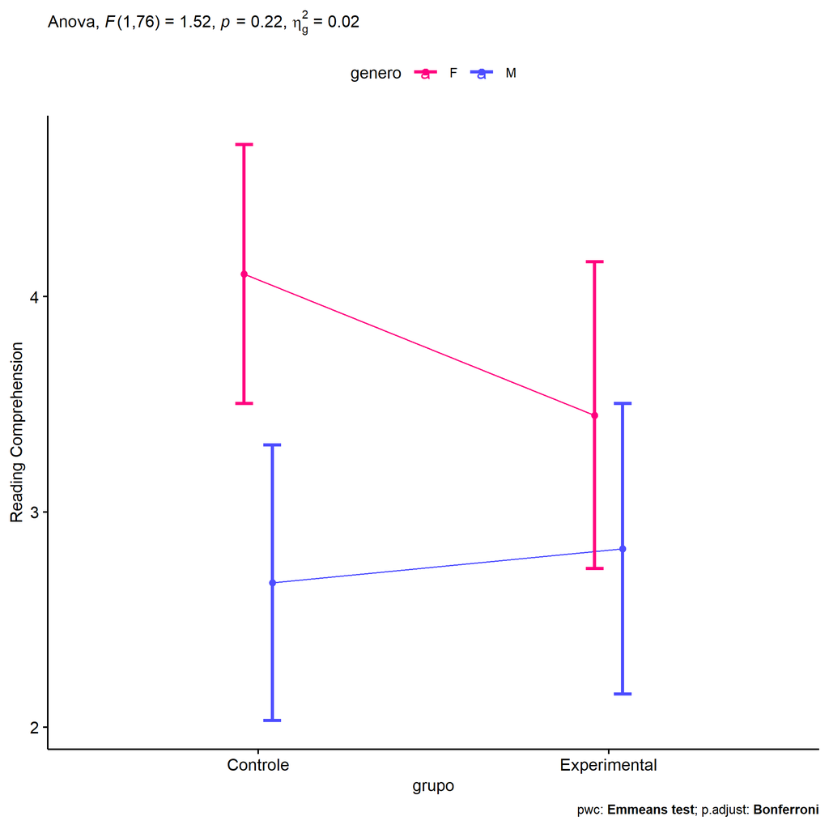

```r
if (length(unique(pdat[["genero"]])) >= 2) {
  ggPlotAoC2(pwcs, "grupo", "genero", aov, ylab = "Reading Comprehension",
             subtitle = which(aov$Effect == "grupo:genero"), addParam = "errorbar") +
    ggplot2::scale_color_manual(values = color[["genero"]]) +
    ggplot2::ylab("Reading Comprehension") +
    if (ymin.ci < ymax.ci) ggplot2::ylim(ymin.ci, ymax.ci)
}
```

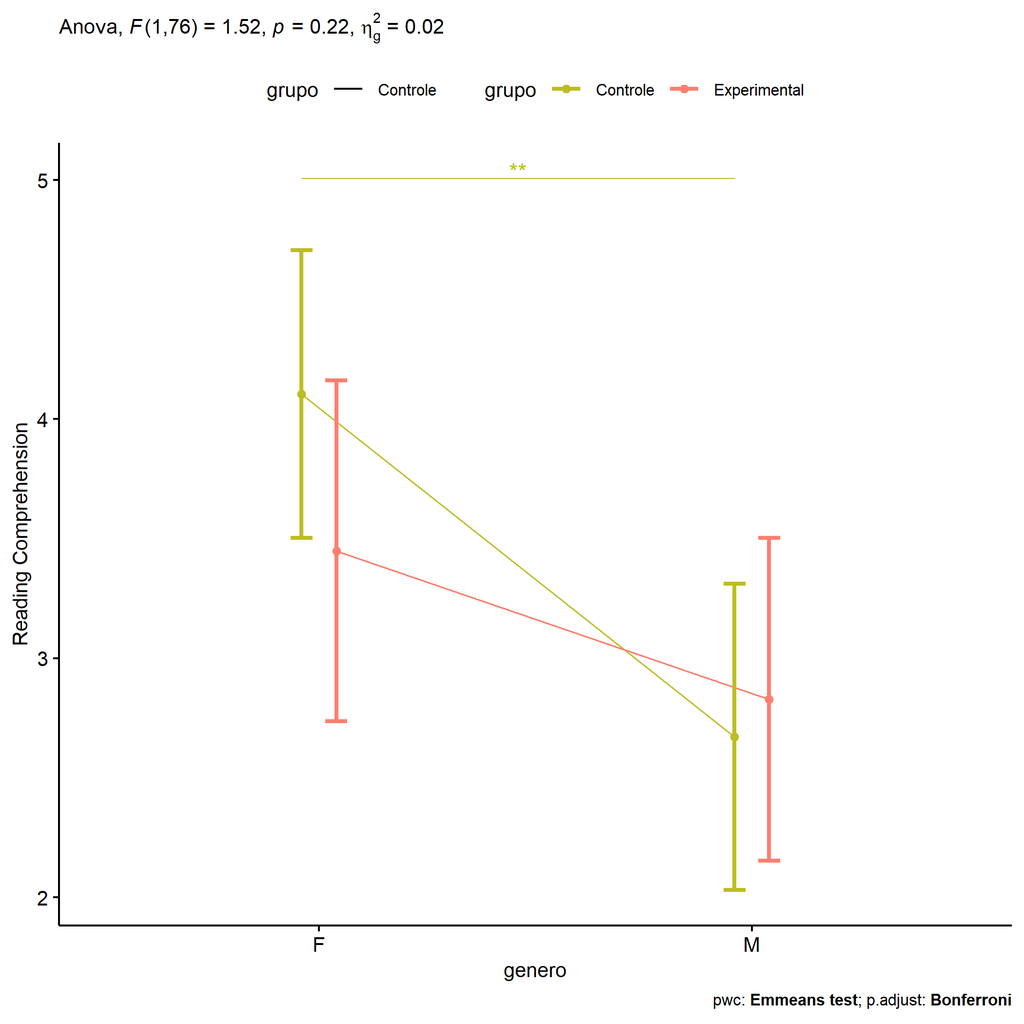

```r
if (length(unique(pdat[["genero"]])) >= 2) {
  ggPlotAoC2(pwcs, "genero", "grupo", aov, ylab = "Reading Comprehension",
               subtitle = which(aov$Effect == "grupo:genero"), addParam = "errorbar") +
    ggplot2::scale_color_manual(values = color[["grupo"]]) +
    ggplot2::ylab("Reading Comprehension") +
    if (ymin.ci < ymax.ci) ggplot2::ylim(ymin.ci, ymax.ci)
}
```

```r
if (length(unique(pdat[["genero"]])) >= 2) {
  plots <- twoWayAncovaBoxPlots(
    wdat, "score.compreensao.pos", c("grupo","genero"), aov, pwcs, covar = "score.compreensao.pre",
    theme = "classic", color = color[["grupo:genero"]],
    subtitle = which(aov$Effect == "grupo:genero"))
}
```

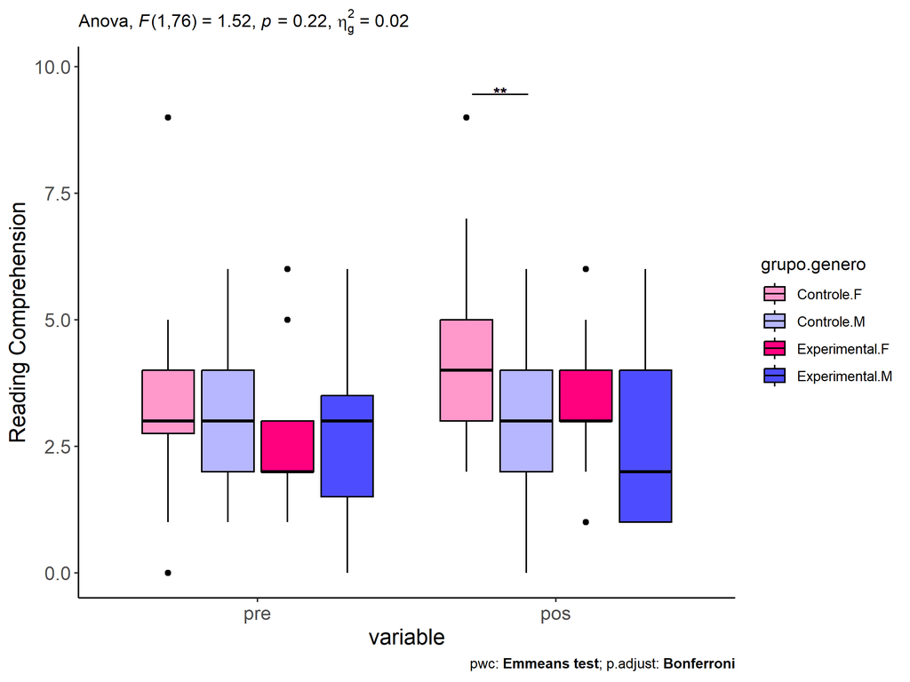

```r
if (length(unique(pdat[["genero"]])) >= 2) {
  plots[["grupo:genero"]] + ggplot2::ylab("Reading Comprehension") +
  ggplot2::scale_x_discrete(labels=c('pre', 'pos')) +
  if (ymin < ymax) ggplot2::ylim(ymin, ymax)
}
```

```r
if (length(unique(pdat[["genero"]])) >= 2) {
  plots <- twoWayAncovaBoxPlots(
    wdat.long, "score.compreensao", c("grupo","genero"), aov, pwc.long,
    pre.post = "time",
    theme = "classic", color = color$prepost)
}
```

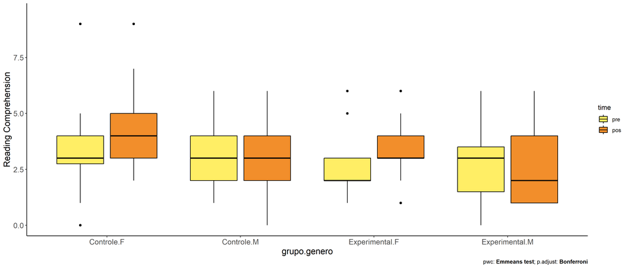

```r
if (length(unique(pdat[["genero"]])) >= 2)
  plots[["grupo:genero"]] + ggplot2::ylab("Reading Comprehension") +
    if (ymin < ymax) ggplot2::ylim(ymin, ymax)
```

### Checking linearity assumption

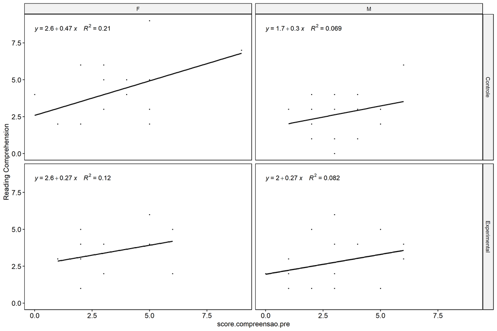

```r
if (length(unique(pdat[["genero"]])) >= 2) {
  ggscatter(wdat, x = "score.compreensao.pre", y = "score.compreensao.pos", size = 0.5,
            facet.by = c("grupo","genero"), add = "reg.line")+
    stat_regline_equation(
      aes(label =  paste(..eq.label.., ..rr.label.., sep = "~~~~"))
    ) + ggplot2::ylab("Reading Comprehension") +
    if (ymin < ymax) ggplot2::ylim(ymin, ymax)
}
```

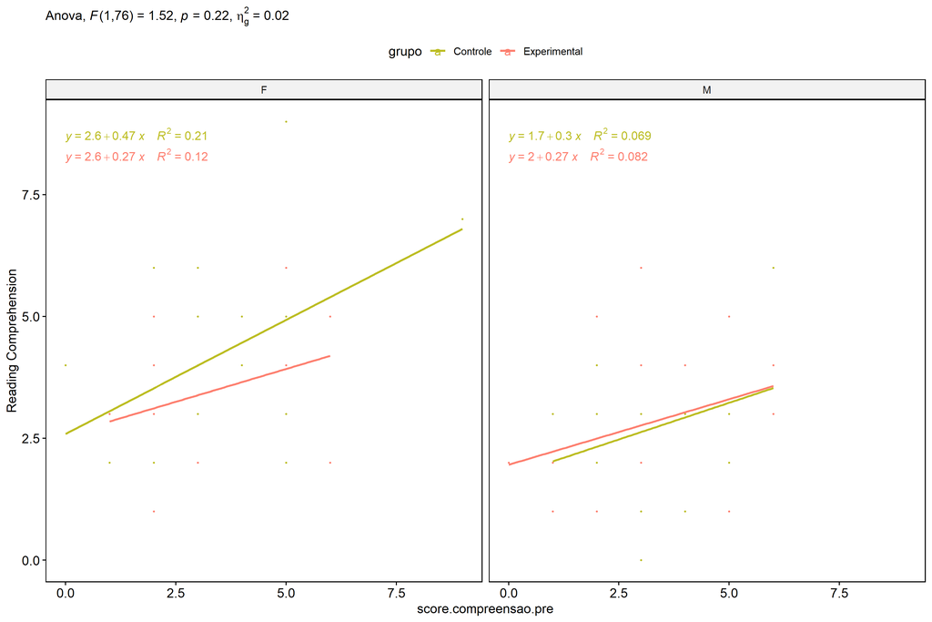

```r
if (length(unique(pdat[["genero"]])) >= 2) {
  ggscatter(wdat, x = "score.compreensao.pre", y = "score.compreensao.pos", size = 0.5,
            color = "grupo", facet.by = "genero", add = "reg.line")+
    stat_regline_equation(
      aes(label =  paste(..eq.label.., ..rr.label.., sep = "~~~~"), color = grupo)
    ) +
    ggplot2::labs(subtitle = rstatix::get_test_label(aov, detailed = T, row = which(aov$Effect == "grupo:genero"))) +
    ggplot2::scale_color_manual(values = color[["grupo"]]) +
    ggplot2::ylab("Reading Comprehension") +
    if (ymin < ymax) ggplot2::ylim(ymin, ymax)
}
```

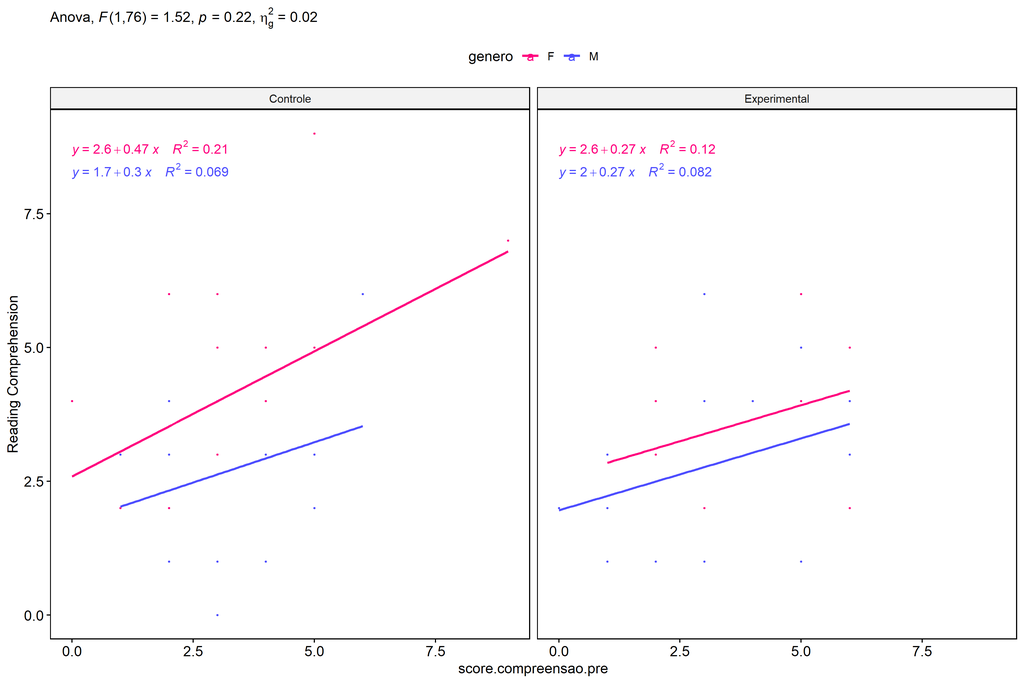

```r
if (length(unique(pdat[["genero"]])) >= 2) {
  ggscatter(wdat, x = "score.compreensao.pre", y = "score.compreensao.pos", size = 0.5,
            color = "genero", facet.by = "grupo", add = "reg.line")+
    stat_regline_equation(
      aes(label =  paste(..eq.label.., ..rr.label.., sep = "~~~~"), color = genero)
    ) +
    ggplot2::labs(subtitle = rstatix::get_test_label(aov, detailed = T, row = which(aov$Effect == "grupo:genero"))) +
    ggplot2::scale_color_manual(values = color[["genero"]]) +
    ggplot2::ylab("Reading Comprehension") +
    if (ymin < ymax) ggplot2::ylim(ymin, ymax)
}
```

### Checking normality and homogeneity

```r
if (length(unique(pdat[["genero"]])) >= 2)
  res <- augment(lm(score.compreensao.pos ~ score.compreensao.pre + grupo*genero, data = wdat))
```

```r
if (length(unique(pdat[["genero"]])) >= 2)
  shapiro_test(res$.resid)
```

```
## # A tibble: 1 × 3
##   variable   statistic p.value
##   <chr>          <dbl>   <dbl>
## 1 res$.resid     0.981   0.275
```

```r
if (length(unique(pdat[["genero"]])) >= 2)
  levene_test(res, .resid ~ grupo*genero)
```

```
## # A tibble: 1 × 4
##     df1   df2 statistic     p
##   <int> <int>     <dbl> <dbl>
## 1     3    77      1.64 0.187
```

# ANCOVA and Pairwise for two factors **grupo:zona.participante**

## Without remove non-normal data

```r
pdat = remove_group_data(dat[!is.na(dat[["grupo"]]) & !is.na(dat[["zona.participante"]]),],
                         "score.compreensao.pos", c("grupo","zona.participante"))
pdat = pdat[pdat[["zona.participante"]] %in% do.call(
  intersect, lapply(unique(pdat[["grupo"]]), FUN = function(x) {
    unique(pdat[["zona.participante"]][which(pdat[["grupo"]] == x)])
  })),]
pdat[["grupo"]] = factor(pdat[["grupo"]], level[["grupo"]])
pdat[["zona.participante"]] = factor(
  pdat[["zona.participante"]],
  level[["zona.participante"]][level[["zona.participante"]] %in% unique(pdat[["zona.participante"]])])

pdat.long <- rbind(pdat[,c("id","grupo","zona.participante")], pdat[,c("id","grupo","zona.participante")])
pdat.long[["time"]] <- c(rep("pre", nrow(pdat)), rep("pos", nrow(pdat)))
pdat.long[["time"]] <- factor(pdat.long[["time"]], c("pre","pos"))
pdat.long[["score.compreensao"]] <- c(pdat[["score.compreensao.pre"]], pdat[["score.compreensao.pos"]])

if (length(unique(pdat[["zona.participante"]])) >= 2) {
  aov = anova_test(pdat, score.compreensao.pos ~ score.compreensao.pre + grupo*zona.participante)
  laov[["grupo:zona.participante"]] <- get_anova_table(aov)
}
```

```r
if (length(unique(pdat[["zona.participante"]])) >= 2) {
  pwcs <- list()
  pwcs[["zona.participante"]] <- emmeans_test(
    group_by(pdat, grupo), score.compreensao.pos ~ zona.participante,
    covariate = score.compreensao.pre, p.adjust.method = "bonferroni")
  pwcs[["grupo"]] <- emmeans_test(
    group_by(pdat, zona.participante), score.compreensao.pos ~ grupo,
    covariate = score.compreensao.pre, p.adjust.method = "bonferroni")

  pwc <- plyr::rbind.fill(pwcs[["grupo"]], pwcs[["zona.participante"]])
  pwc <- pwc[,c("grupo","zona.participante", colnames(pwc)[!colnames(pwc) %in% c("grupo","zona.participante")])]
}
```

```r
if (length(unique(pdat[["zona.participante"]])) >= 2) {
  pwc.long <- emmeans_test(dplyr::group_by_at(pdat.long, c("grupo","zona.participante")),
                           score.compreensao ~ time,
                           p.adjust.method = "bonferroni")
  lpwc[["grupo:zona.participante"]] <- plyr::rbind.fill(pwc, pwc.long)
}
```

```r
if (length(unique(pdat[["zona.participante"]])) >= 2) {
  ds <- get.descriptives(pdat, "score.compreensao.pos", c("grupo","zona.participante"), covar = "score.compreensao.pre")
  ds <- merge(ds[ds$variable != "score.compreensao.pre",],
              ds[ds$variable == "score.compreensao.pre", !colnames(ds) %in% c("variable")],
              by = c("grupo","zona.participante"), all.x = T, suffixes = c("", ".score.compreensao.pre"))
  ds <- merge(get_emmeans(pwcs[["grupo"]]), ds,
              by = c("grupo","zona.participante"), suffixes = c(".emms", ""))
  ds <- ds[,c("grupo","zona.participante","n","mean.score.compreensao.pre","se.score.compreensao.pre","mean","se",
              "emmean","se.emms","conf.low","conf.high")]

  colnames(ds) <- c("grupo","zona.participante", "N", paste0(c("M","SE")," (pre)"),
                    paste0(c("M","SE"), " (unadj)"),
                    paste0(c("M", "SE"), " (adj)"), "conf.low", "conf.high")

  lemms[["grupo:zona.participante"]] <- ds
}
```

## Computing ANCOVA and PairWise After removing non-normal data (OK)

```r
if (length(unique(pdat[["zona.participante"]])) >= 2) {
  wdat = pdat

  res = residuals(lm(score.compreensao.pos ~ score.compreensao.pre + grupo*zona.participante, data = wdat))
  non.normal = getNonNormal(res, wdat$id, plimit = 0.05)

  wdat = wdat[!wdat$id %in% non.normal,]

  wdat.long <- rbind(wdat[,c("id","grupo","zona.participante")], wdat[,c("id","grupo","zona.participante")])
  wdat.long[["time"]] <- c(rep("pre", nrow(wdat)), rep("pos", nrow(wdat)))
  wdat.long[["time"]] <- factor(wdat.long[["time"]], c("pre","pos"))
  wdat.long[["score.compreensao"]] <- c(wdat[["score.compreensao.pre"]], wdat[["score.compreensao.pos"]])


  ldat[["grupo:zona.participante"]] = wdat

  (non.normal)
}
```

```
## [1] "P270"
```

```r
if (length(unique(pdat[["zona.participante"]])) >= 2) {
  aov = anova_test(wdat, score.compreensao.pos ~ score.compreensao.pre + grupo*zona.participante)
  laov[["grupo:zona.participante"]] <- merge(get_anova_table(aov), laov[["grupo:zona.participante"]],
                                         by="Effect", suffixes = c("","'"))
  df = get_anova_table(aov)
}
```

| Effect | DFn | DFd | F | p | p<.05 | ges |
| --- | --- | --- | --- | --- | --- | --- |
| score.compreensao.pre | 1 | 56 | 10.219 | 0.002 | * | 0.154 |
| grupo | 1 | 56 | 1.373 | 0.246 |  | 0.024 |
| zona.participante | 1 | 56 | 0.341 | 0.561 |  | 0.006 |
| grupo:zona.participante | 1 | 56 | 0.001 | 0.970 |  | 0.000 |

```r
if (length(unique(pdat[["zona.participante"]])) >= 2) {
  pwcs <- list()
  pwcs[["zona.participante"]] <- emmeans_test(
    group_by(wdat, grupo), score.compreensao.pos ~ zona.participante,
    covariate = score.compreensao.pre, p.adjust.method = "bonferroni")
  pwcs[["grupo"]] <- emmeans_test(
    group_by(wdat, zona.participante), score.compreensao.pos ~ grupo,
    covariate = score.compreensao.pre, p.adjust.method = "bonferroni")

  pwc <- plyr::rbind.fill(pwcs[["grupo"]], pwcs[["zona.participante"]])
  pwc <- pwc[,c("grupo","zona.participante", colnames(pwc)[!colnames(pwc) %in% c("grupo","zona.participante")])]
}
```

| grupo | zona.participante | term | .y. | group1 | group2 | df | statistic | p | p.adj | p.adj.signif |
| --- | --- | --- | --- | --- | --- | --- | --- | --- | --- | --- |
|  | Rural | score.compreensao.pre*grupo | score.compreensao.pos | Controle | Experimental | 56 | 0.841 | 0.404 | 0.404 | ns |
|  | Urbana | score.compreensao.pre*grupo | score.compreensao.pos | Controle | Experimental | 56 | 0.821 | 0.415 | 0.415 | ns |
| Controle |  | score.compreensao.pre*zona.participante | score.compreensao.pos | Rural | Urbana | 56 | -0.410 | 0.683 | 0.683 | ns |
| Experimental |  | score.compreensao.pre*zona.participante | score.compreensao.pos | Rural | Urbana | 56 | -0.411 | 0.683 | 0.683 | ns |

```r
if (length(unique(pdat[["zona.participante"]])) >= 2) {
  pwc.long <- emmeans_test(dplyr::group_by_at(wdat.long, c("grupo","zona.participante")),
                           score.compreensao ~ time,
                           p.adjust.method = "bonferroni")
  lpwc[["grupo:zona.participante"]] <- merge(plyr::rbind.fill(pwc, pwc.long),
                                         lpwc[["grupo:zona.participante"]],
                                         by=c("grupo","zona.participante","term",".y.","group1","group2"),
                                         suffixes = c("","'"))
}
```

| grupo | zona.participante | term | .y. | group1 | group2 | df | statistic | p | p.adj | p.adj.signif |
| --- | --- | --- | --- | --- | --- | --- | --- | --- | --- | --- |
| Controle | Rural | time | score.compreensao | pre | pos | 114 | -0.380 | 0.705 | 0.705 | ns |
| Controle | Urbana | time | score.compreensao | pre | pos | 114 | -0.641 | 0.523 | 0.523 | ns |
| Experimental | Rural | time | score.compreensao | pre | pos | 114 | 0.352 | 0.726 | 0.726 | ns |
| Experimental | Urbana | time | score.compreensao | pre | pos | 114 | -1.140 | 0.257 | 0.257 | ns |

```r
if (length(unique(pdat[["zona.participante"]])) >= 2) {
  ds <- get.descriptives(wdat, "score.compreensao.pos", c("grupo","zona.participante"), covar = "score.compreensao.pre")
  ds <- merge(ds[ds$variable != "score.compreensao.pre",],
              ds[ds$variable == "score.compreensao.pre", !colnames(ds) %in% c("variable")],
              by = c("grupo","zona.participante"), all.x = T, suffixes = c("", ".score.compreensao.pre"))
  ds <- merge(get_emmeans(pwcs[["grupo"]]), ds,
              by = c("grupo","zona.participante"), suffixes = c(".emms", ""))
  ds <- ds[,c("grupo","zona.participante","n","mean.score.compreensao.pre","se.score.compreensao.pre",
              "mean","se","emmean","se.emms","conf.low","conf.high")]

  colnames(ds) <- c("grupo","zona.participante", "N", paste0(c("M","SE")," (pre)"),
                    paste0(c("M","SE"), " (unadj)"),
                    paste0(c("M", "SE"), " (adj)"), "conf.low", "conf.high")

  lemms[["grupo:zona.participante"]] <- merge(ds, lemms[["grupo:zona.participante"]],
                                          by=c("grupo","zona.participante"), suffixes = c("","'"))
}
```

| grupo | zona.participante | N | M (pre) | SE (pre) | M (unadj) | SE (unadj) | M (adj) | SE (adj) | conf.low | conf.high |
| --- | --- | --- | --- | --- | --- | --- | --- | --- | --- | --- |
| Controle | Rural | 12 | 3.417 | 0.260 | 3.667 | 0.284 | 3.605 | 0.437 | 2.730 | 4.480 |
| Controle | Urbana | 23 | 3.696 | 0.364 | 4.000 | 0.431 | 3.826 | 0.320 | 3.185 | 4.467 |
| Experimental | Rural | 14 | 3.357 | 0.498 | 3.143 | 0.361 | 3.105 | 0.404 | 2.295 | 3.914 |
| Experimental | Urbana | 12 | 2.167 | 0.423 | 2.917 | 0.417 | 3.357 | 0.458 | 2.440 | 4.273 |

### Plots for ancova

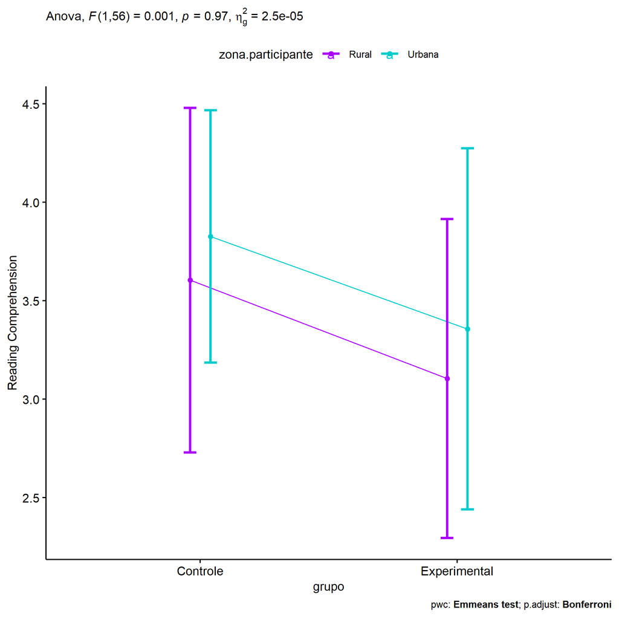

```r
if (length(unique(pdat[["zona.participante"]])) >= 2) {
  ggPlotAoC2(pwcs, "grupo", "zona.participante", aov, ylab = "Reading Comprehension",
             subtitle = which(aov$Effect == "grupo:zona.participante"), addParam = "errorbar") +
    ggplot2::scale_color_manual(values = color[["zona.participante"]]) +
    ggplot2::ylab("Reading Comprehension") +
    if (ymin.ci < ymax.ci) ggplot2::ylim(ymin.ci, ymax.ci)
}
```

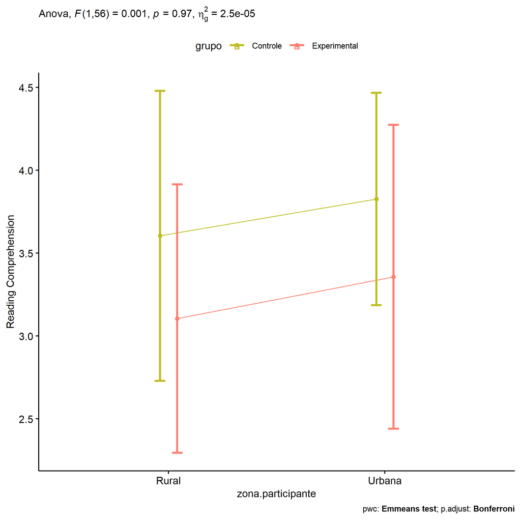

```r
if (length(unique(pdat[["zona.participante"]])) >= 2) {
  ggPlotAoC2(pwcs, "zona.participante", "grupo", aov, ylab = "Reading Comprehension",
               subtitle = which(aov$Effect == "grupo:zona.participante"), addParam = "errorbar") +
    ggplot2::scale_color_manual(values = color[["grupo"]]) +
    ggplot2::ylab("Reading Comprehension") +
    if (ymin.ci < ymax.ci) ggplot2::ylim(ymin.ci, ymax.ci)
}
```

```r
if (length(unique(pdat[["zona.participante"]])) >= 2) {
  plots <- twoWayAncovaBoxPlots(
    wdat, "score.compreensao.pos", c("grupo","zona.participante"), aov, pwcs, covar = "score.compreensao.pre",
    theme = "classic", color = color[["grupo:zona.participante"]],
    subtitle = which(aov$Effect == "grupo:zona.participante"))
}
```

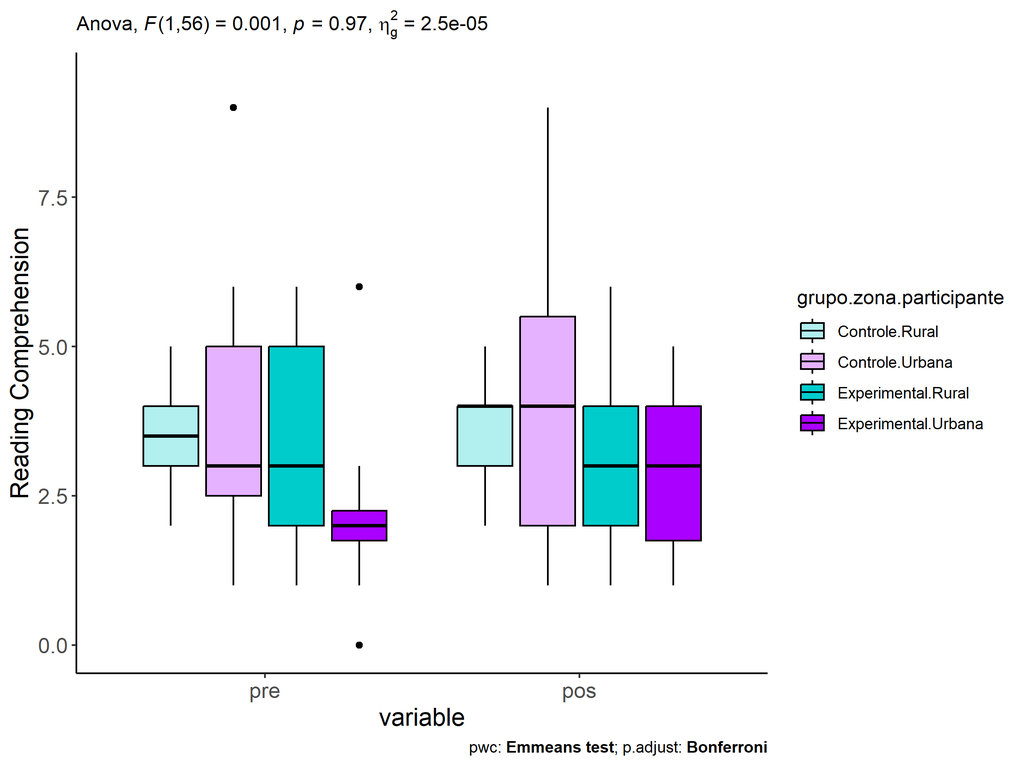

```r
if (length(unique(pdat[["zona.participante"]])) >= 2) {
  plots[["grupo:zona.participante"]] + ggplot2::ylab("Reading Comprehension") +
  ggplot2::scale_x_discrete(labels=c('pre', 'pos')) +
  if (ymin < ymax) ggplot2::ylim(ymin, ymax)
}
```

```r
if (length(unique(pdat[["zona.participante"]])) >= 2) {
  plots <- twoWayAncovaBoxPlots(
    wdat.long, "score.compreensao", c("grupo","zona.participante"), aov, pwc.long,
    pre.post = "time",
    theme = "classic", color = color$prepost)
}
```

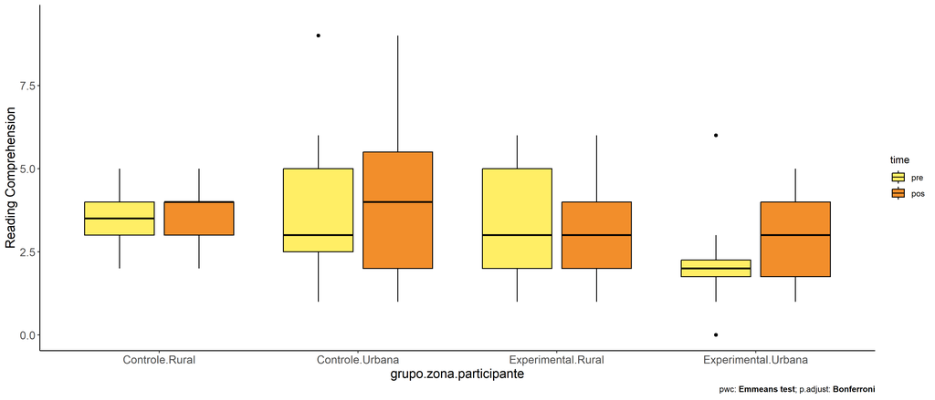

```r
if (length(unique(pdat[["zona.participante"]])) >= 2)
  plots[["grupo:zona.participante"]] + ggplot2::ylab("Reading Comprehension") +
    if (ymin < ymax) ggplot2::ylim(ymin, ymax)
```

### Checking linearity assumption

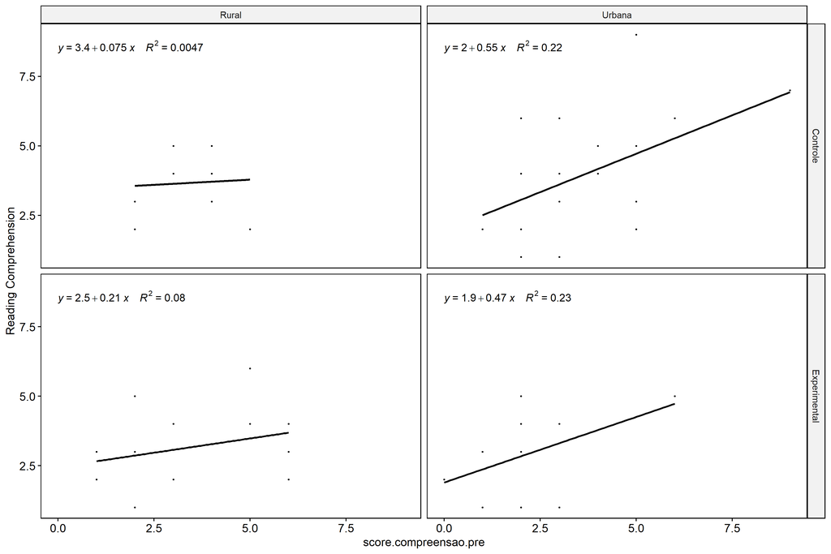

```r
if (length(unique(pdat[["zona.participante"]])) >= 2) {
  ggscatter(wdat, x = "score.compreensao.pre", y = "score.compreensao.pos", size = 0.5,
            facet.by = c("grupo","zona.participante"), add = "reg.line")+
    stat_regline_equation(
      aes(label =  paste(..eq.label.., ..rr.label.., sep = "~~~~"))
    ) + ggplot2::ylab("Reading Comprehension") +
    if (ymin < ymax) ggplot2::ylim(ymin, ymax)
}
```

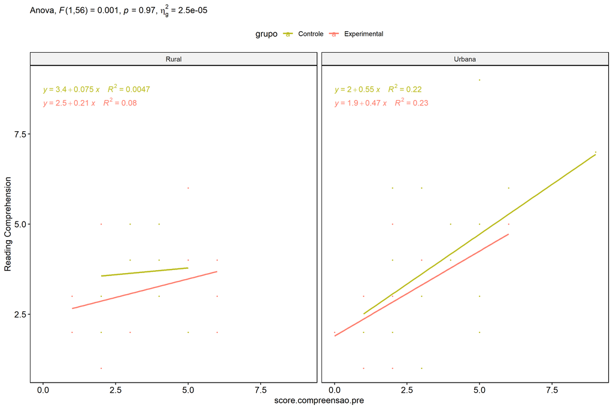

```r
if (length(unique(pdat[["zona.participante"]])) >= 2) {
  ggscatter(wdat, x = "score.compreensao.pre", y = "score.compreensao.pos", size = 0.5,
            color = "grupo", facet.by = "zona.participante", add = "reg.line")+
    stat_regline_equation(
      aes(label =  paste(..eq.label.., ..rr.label.., sep = "~~~~"), color = grupo)
    ) +
    ggplot2::labs(subtitle = rstatix::get_test_label(aov, detailed = T, row = which(aov$Effect == "grupo:zona.participante"))) +
    ggplot2::scale_color_manual(values = color[["grupo"]]) +
    ggplot2::ylab("Reading Comprehension") +
    if (ymin < ymax) ggplot2::ylim(ymin, ymax)
}
```

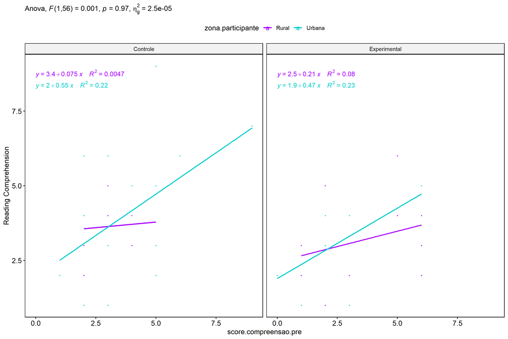

```r
if (length(unique(pdat[["zona.participante"]])) >= 2) {
  ggscatter(wdat, x = "score.compreensao.pre", y = "score.compreensao.pos", size = 0.5,
            color = "zona.participante", facet.by = "grupo", add = "reg.line")+
    stat_regline_equation(
      aes(label =  paste(..eq.label.., ..rr.label.., sep = "~~~~"), color = zona.participante)
    ) +
    ggplot2::labs(subtitle = rstatix::get_test_label(aov, detailed = T, row = which(aov$Effect == "grupo:zona.participante"))) +
    ggplot2::scale_color_manual(values = color[["zona.participante"]]) +
    ggplot2::ylab("Reading Comprehension") +
    if (ymin < ymax) ggplot2::ylim(ymin, ymax)
}
```

### Checking normality and homogeneity

```r
if (length(unique(pdat[["zona.participante"]])) >= 2)
  res <- augment(lm(score.compreensao.pos ~ score.compreensao.pre + grupo*zona.participante, data = wdat))
```

```r
if (length(unique(pdat[["zona.participante"]])) >= 2)
  shapiro_test(res$.resid)
```

```
## # A tibble: 1 × 3
##   variable   statistic p.value
##   <chr>          <dbl>   <dbl>
## 1 res$.resid     0.970   0.145
```

```r
if (length(unique(pdat[["zona.participante"]])) >= 2)
  levene_test(res, .resid ~ grupo*zona.participante)
```

```
## # A tibble: 1 × 4
##     df1   df2 statistic     p
##   <int> <int>     <dbl> <dbl>
## 1     3    57      2.14 0.105
```

# ANCOVA and Pairwise for two factors **grupo:zona.escola**

## Without remove non-normal data

```r
pdat = remove_group_data(dat[!is.na(dat[["grupo"]]) & !is.na(dat[["zona.escola"]]),],
                         "score.compreensao.pos", c("grupo","zona.escola"))
pdat = pdat[pdat[["zona.escola"]] %in% do.call(
  intersect, lapply(unique(pdat[["grupo"]]), FUN = function(x) {
    unique(pdat[["zona.escola"]][which(pdat[["grupo"]] == x)])
  })),]
pdat[["grupo"]] = factor(pdat[["grupo"]], level[["grupo"]])
pdat[["zona.escola"]] = factor(
  pdat[["zona.escola"]],
  level[["zona.escola"]][level[["zona.escola"]] %in% unique(pdat[["zona.escola"]])])

pdat.long <- rbind(pdat[,c("id","grupo","zona.escola")], pdat[,c("id","grupo","zona.escola")])
pdat.long[["time"]] <- c(rep("pre", nrow(pdat)), rep("pos", nrow(pdat)))
pdat.long[["time"]] <- factor(pdat.long[["time"]], c("pre","pos"))
pdat.long[["score.compreensao"]] <- c(pdat[["score.compreensao.pre"]], pdat[["score.compreensao.pos"]])

if (length(unique(pdat[["zona.escola"]])) >= 2) {
  aov = anova_test(pdat, score.compreensao.pos ~ score.compreensao.pre + grupo*zona.escola)
  laov[["grupo:zona.escola"]] <- get_anova_table(aov)
}
```

```r
if (length(unique(pdat[["zona.escola"]])) >= 2) {
  pwcs <- list()
  pwcs[["zona.escola"]] <- emmeans_test(
    group_by(pdat, grupo), score.compreensao.pos ~ zona.escola,
    covariate = score.compreensao.pre, p.adjust.method = "bonferroni")
  pwcs[["grupo"]] <- emmeans_test(
    group_by(pdat, zona.escola), score.compreensao.pos ~ grupo,
    covariate = score.compreensao.pre, p.adjust.method = "bonferroni")

  pwc <- plyr::rbind.fill(pwcs[["grupo"]], pwcs[["zona.escola"]])
  pwc <- pwc[,c("grupo","zona.escola", colnames(pwc)[!colnames(pwc) %in% c("grupo","zona.escola")])]
}
```

```r
if (length(unique(pdat[["zona.escola"]])) >= 2) {
  pwc.long <- emmeans_test(dplyr::group_by_at(pdat.long, c("grupo","zona.escola")),
                           score.compreensao ~ time,
                           p.adjust.method = "bonferroni")
  lpwc[["grupo:zona.escola"]] <- plyr::rbind.fill(pwc, pwc.long)
}
```

```r
if (length(unique(pdat[["zona.escola"]])) >= 2) {
  ds <- get.descriptives(pdat, "score.compreensao.pos", c("grupo","zona.escola"), covar = "score.compreensao.pre")
  ds <- merge(ds[ds$variable != "score.compreensao.pre",],
              ds[ds$variable == "score.compreensao.pre", !colnames(ds) %in% c("variable")],
              by = c("grupo","zona.escola"), all.x = T, suffixes = c("", ".score.compreensao.pre"))
  ds <- merge(get_emmeans(pwcs[["grupo"]]), ds,
              by = c("grupo","zona.escola"), suffixes = c(".emms", ""))
  ds <- ds[,c("grupo","zona.escola","n","mean.score.compreensao.pre","se.score.compreensao.pre","mean","se",
              "emmean","se.emms","conf.low","conf.high")]

  colnames(ds) <- c("grupo","zona.escola", "N", paste0(c("M","SE")," (pre)"),
                    paste0(c("M","SE"), " (unadj)"),
                    paste0(c("M", "SE"), " (adj)"), "conf.low", "conf.high")

  lemms[["grupo:zona.escola"]] <- ds
}
```

## Computing ANCOVA and PairWise After removing non-normal data (OK)

```r
if (length(unique(pdat[["zona.escola"]])) >= 2) {
  wdat = pdat

  res = residuals(lm(score.compreensao.pos ~ score.compreensao.pre + grupo*zona.escola, data = wdat))
  non.normal = getNonNormal(res, wdat$id, plimit = 0.05)

  wdat = wdat[!wdat$id %in% non.normal,]

  wdat.long <- rbind(wdat[,c("id","grupo","zona.escola")], wdat[,c("id","grupo","zona.escola")])
  wdat.long[["time"]] <- c(rep("pre", nrow(wdat)), rep("pos", nrow(wdat)))
  wdat.long[["time"]] <- factor(wdat.long[["time"]], c("pre","pos"))
  wdat.long[["score.compreensao"]] <- c(wdat[["score.compreensao.pre"]], wdat[["score.compreensao.pos"]])


  ldat[["grupo:zona.escola"]] = wdat

  (non.normal)
}
```

```
## [1] "P270"
```

```r
if (length(unique(pdat[["zona.escola"]])) >= 2) {
  aov = anova_test(wdat, score.compreensao.pos ~ score.compreensao.pre + grupo*zona.escola)
  laov[["grupo:zona.escola"]] <- merge(get_anova_table(aov), laov[["grupo:zona.escola"]],
                                         by="Effect", suffixes = c("","'"))
  df = get_anova_table(aov)
}
```

| Effect | DFn | DFd | F | p | p<.05 | ges |
| --- | --- | --- | --- | --- | --- | --- |
| score.compreensao.pre | 1 | 76 | 9.031 | 0.004 | * | 0.106 |
| grupo | 1 | 76 | 0.879 | 0.351 |  | 0.011 |
| zona.escola | 1 | 76 | 1.061 | 0.306 |  | 0.014 |
| grupo:zona.escola | 1 | 76 | 0.105 | 0.747 |  | 0.001 |

```r
if (length(unique(pdat[["zona.escola"]])) >= 2) {
  pwcs <- list()
  pwcs[["zona.escola"]] <- emmeans_test(
    group_by(wdat, grupo), score.compreensao.pos ~ zona.escola,
    covariate = score.compreensao.pre, p.adjust.method = "bonferroni")
  pwcs[["grupo"]] <- emmeans_test(
    group_by(wdat, zona.escola), score.compreensao.pos ~ grupo,
    covariate = score.compreensao.pre, p.adjust.method = "bonferroni")

  pwc <- plyr::rbind.fill(pwcs[["grupo"]], pwcs[["zona.escola"]])
  pwc <- pwc[,c("grupo","zona.escola", colnames(pwc)[!colnames(pwc) %in% c("grupo","zona.escola")])]
}
```

| grupo | zona.escola | term | .y. | group1 | group2 | df | statistic | p | p.adj | p.adj.signif |
| --- | --- | --- | --- | --- | --- | --- | --- | --- | --- | --- |
|  | Rural | score.compreensao.pre*grupo | score.compreensao.pos | Controle | Experimental | 76 | 0.254 | 0.800 | 0.800 | ns |
|  | Urbana | score.compreensao.pre*grupo | score.compreensao.pos | Controle | Experimental | 76 | 0.962 | 0.339 | 0.339 | ns |
| Controle |  | score.compreensao.pre*zona.escola | score.compreensao.pos | Rural | Urbana | 76 | 0.528 | 0.599 | 0.599 | ns |
| Experimental |  | score.compreensao.pre*zona.escola | score.compreensao.pos | Rural | Urbana | 76 | 0.945 | 0.348 | 0.348 | ns |

```r
if (length(unique(pdat[["zona.escola"]])) >= 2) {
  pwc.long <- emmeans_test(dplyr::group_by_at(wdat.long, c("grupo","zona.escola")),
                           score.compreensao ~ time,
                           p.adjust.method = "bonferroni")
  lpwc[["grupo:zona.escola"]] <- merge(plyr::rbind.fill(pwc, pwc.long),
                                         lpwc[["grupo:zona.escola"]],
                                         by=c("grupo","zona.escola","term",".y.","group1","group2"),
                                         suffixes = c("","'"))
}
```

| grupo | zona.escola | term | .y. | group1 | group2 | df | statistic | p | p.adj | p.adj.signif |
| --- | --- | --- | --- | --- | --- | --- | --- | --- | --- | --- |
| Controle | Rural | time | score.compreensao | pre | pos | 154 | 0.122 | 0.903 | 0.903 | ns |
| Controle | Urbana | time | score.compreensao | pre | pos | 154 | -0.543 | 0.588 | 0.588 | ns |
| Experimental | Rural | time | score.compreensao | pre | pos | 154 | -0.634 | 0.527 | 0.527 | ns |
| Experimental | Urbana | time | score.compreensao | pre | pos | 154 | 0.000 | 1.000 | 1.000 | ns |

```r
if (length(unique(pdat[["zona.escola"]])) >= 2) {
  ds <- get.descriptives(wdat, "score.compreensao.pos", c("grupo","zona.escola"), covar = "score.compreensao.pre")
  ds <- merge(ds[ds$variable != "score.compreensao.pre",],
              ds[ds$variable == "score.compreensao.pre", !colnames(ds) %in% c("variable")],
              by = c("grupo","zona.escola"), all.x = T, suffixes = c("", ".score.compreensao.pre"))
  ds <- merge(get_emmeans(pwcs[["grupo"]]), ds,
              by = c("grupo","zona.escola"), suffixes = c(".emms", ""))
  ds <- ds[,c("grupo","zona.escola","n","mean.score.compreensao.pre","se.score.compreensao.pre",
              "mean","se","emmean","se.emms","conf.low","conf.high")]

  colnames(ds) <- c("grupo","zona.escola", "N", paste0(c("M","SE")," (pre)"),
                    paste0(c("M","SE"), " (unadj)"),
                    paste0(c("M", "SE"), " (adj)"), "conf.low", "conf.high")

  lemms[["grupo:zona.escola"]] <- merge(ds, lemms[["grupo:zona.escola"]],
                                          by=c("grupo","zona.escola"), suffixes = c("","'"))
}
```

| grupo | zona.escola | N | M (pre) | SE (pre) | M (unadj) | SE (unadj) | M (adj) | SE (adj) | conf.low | conf.high |
| --- | --- | --- | --- | --- | --- | --- | --- | --- | --- | --- |
| Controle | Rural | 13 | 4.000 | 0.506 | 3.923 | 0.445 | 3.634 | 0.447 | 2.745 | 4.524 |
| Controle | Urbana | 32 | 3.125 | 0.237 | 3.344 | 0.329 | 3.356 | 0.278 | 2.802 | 3.910 |
| Experimental | Rural | 12 | 3.000 | 0.408 | 3.417 | 0.398 | 3.472 | 0.454 | 2.567 | 4.377 |
| Experimental | Urbana | 24 | 2.833 | 0.359 | 2.833 | 0.305 | 2.946 | 0.323 | 2.302 | 3.590 |

### Plots for ancova

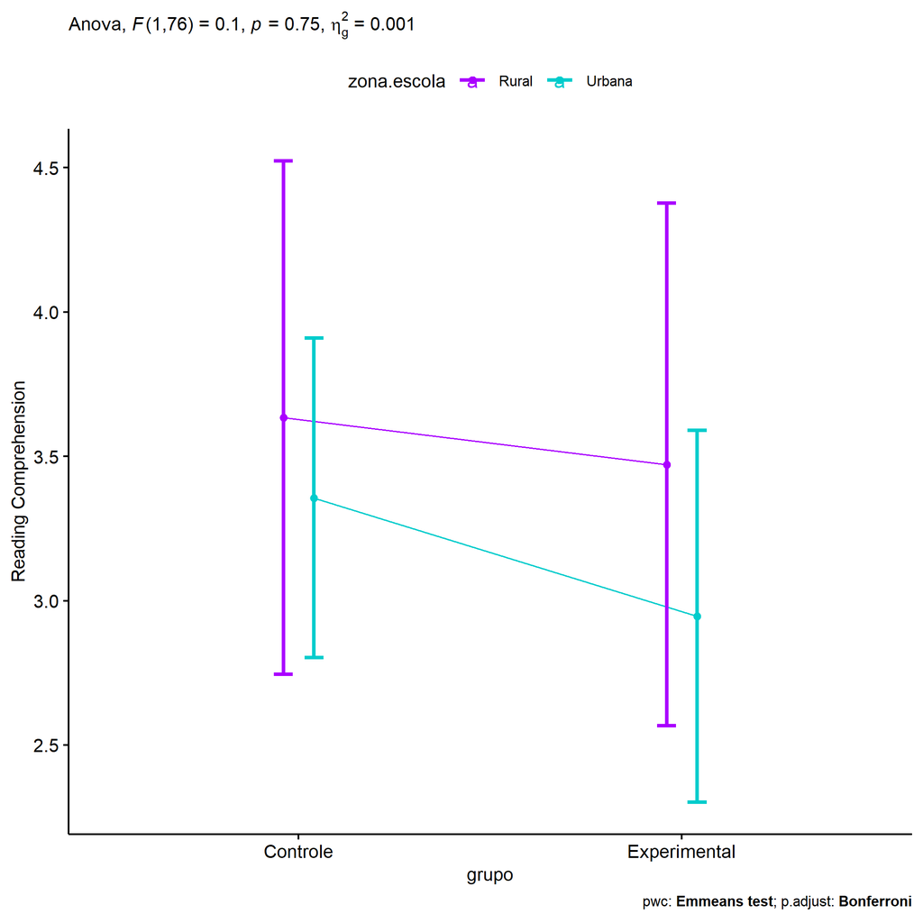

```r
if (length(unique(pdat[["zona.escola"]])) >= 2) {
  ggPlotAoC2(pwcs, "grupo", "zona.escola", aov, ylab = "Reading Comprehension",
             subtitle = which(aov$Effect == "grupo:zona.escola"), addParam = "errorbar") +
    ggplot2::scale_color_manual(values = color[["zona.escola"]]) +
    ggplot2::ylab("Reading Comprehension") +
    if (ymin.ci < ymax.ci) ggplot2::ylim(ymin.ci, ymax.ci)
}
```

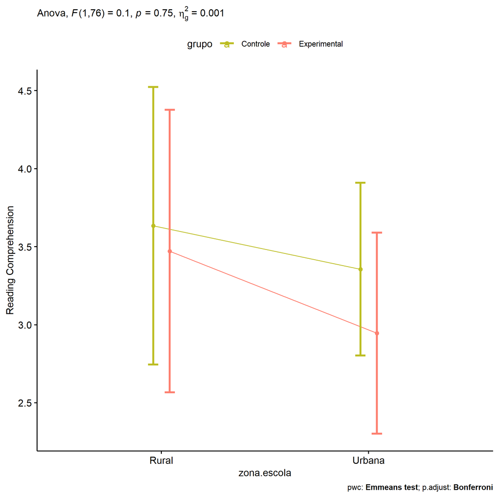

```r
if (length(unique(pdat[["zona.escola"]])) >= 2) {
  ggPlotAoC2(pwcs, "zona.escola", "grupo", aov, ylab = "Reading Comprehension",
               subtitle = which(aov$Effect == "grupo:zona.escola"), addParam = "errorbar") +
    ggplot2::scale_color_manual(values = color[["grupo"]]) +
    ggplot2::ylab("Reading Comprehension") +
    if (ymin.ci < ymax.ci) ggplot2::ylim(ymin.ci, ymax.ci)
}
```

```r
if (length(unique(pdat[["zona.escola"]])) >= 2) {
  plots <- twoWayAncovaBoxPlots(
    wdat, "score.compreensao.pos", c("grupo","zona.escola"), aov, pwcs, covar = "score.compreensao.pre",
    theme = "classic", color = color[["grupo:zona.escola"]],
    subtitle = which(aov$Effect == "grupo:zona.escola"))
}
```

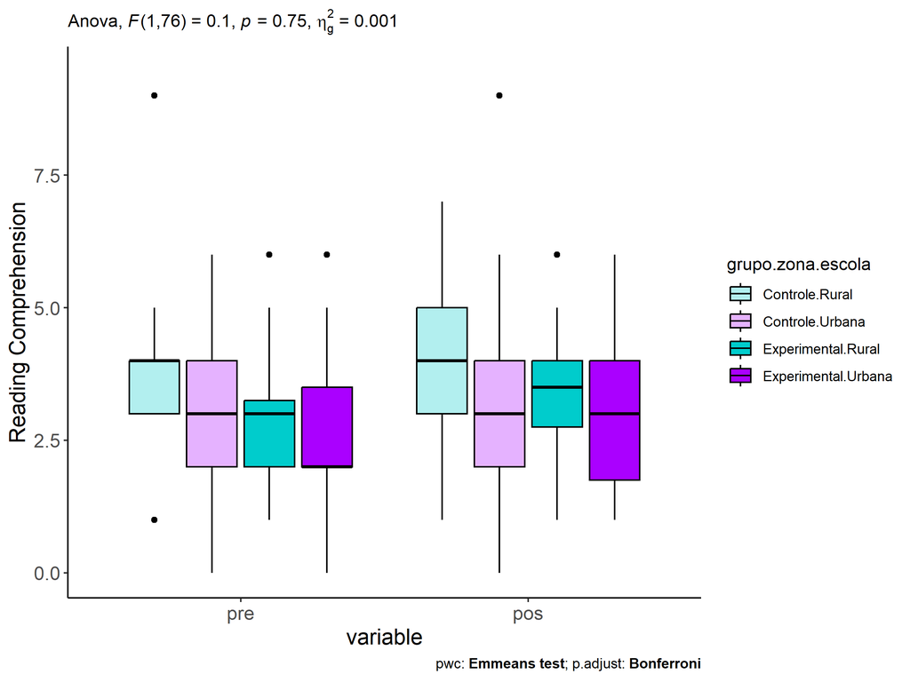

```r
if (length(unique(pdat[["zona.escola"]])) >= 2) {
  plots[["grupo:zona.escola"]] + ggplot2::ylab("Reading Comprehension") +
  ggplot2::scale_x_discrete(labels=c('pre', 'pos')) +
  if (ymin < ymax) ggplot2::ylim(ymin, ymax)
}
```

```r
if (length(unique(pdat[["zona.escola"]])) >= 2) {
  plots <- twoWayAncovaBoxPlots(
    wdat.long, "score.compreensao", c("grupo","zona.escola"), aov, pwc.long,
    pre.post = "time",
    theme = "classic", color = color$prepost)
}
```

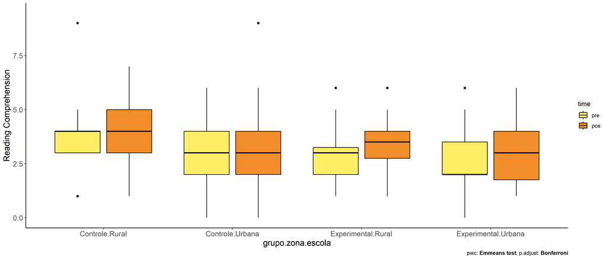

```r
if (length(unique(pdat[["zona.escola"]])) >= 2)
  plots[["grupo:zona.escola"]] + ggplot2::ylab("Reading Comprehension") +
    if (ymin < ymax) ggplot2::ylim(ymin, ymax)
```

### Checking linearity assumption

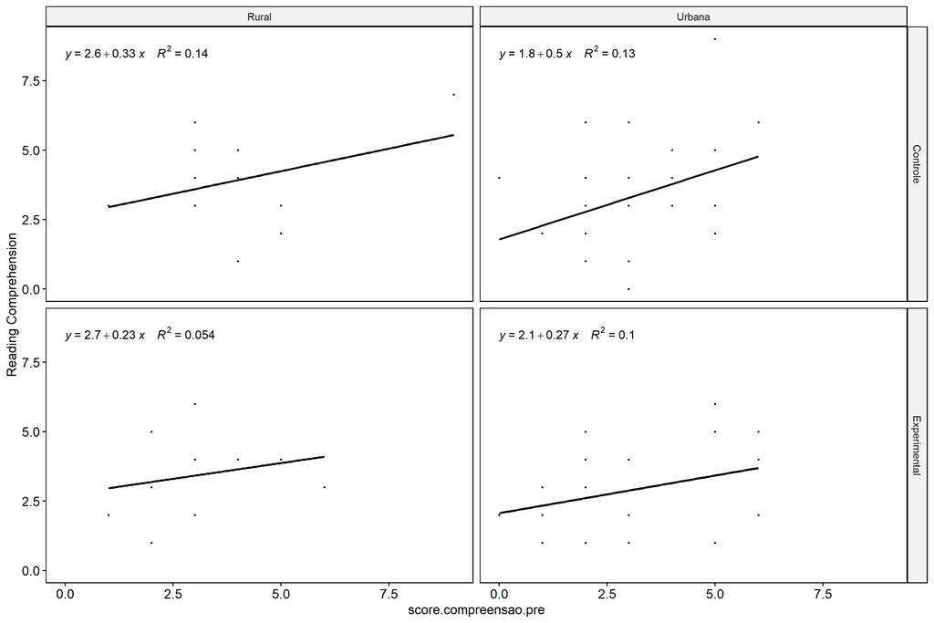

```r
if (length(unique(pdat[["zona.escola"]])) >= 2) {
  ggscatter(wdat, x = "score.compreensao.pre", y = "score.compreensao.pos", size = 0.5,
            facet.by = c("grupo","zona.escola"), add = "reg.line")+
    stat_regline_equation(
      aes(label =  paste(..eq.label.., ..rr.label.., sep = "~~~~"))
    ) + ggplot2::ylab("Reading Comprehension") +
    if (ymin < ymax) ggplot2::ylim(ymin, ymax)
}
```

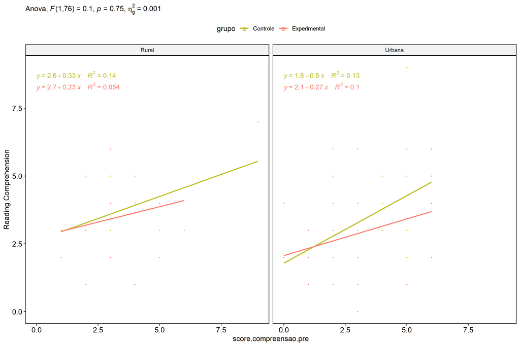

```r
if (length(unique(pdat[["zona.escola"]])) >= 2) {
  ggscatter(wdat, x = "score.compreensao.pre", y = "score.compreensao.pos", size = 0.5,
            color = "grupo", facet.by = "zona.escola", add = "reg.line")+
    stat_regline_equation(
      aes(label =  paste(..eq.label.., ..rr.label.., sep = "~~~~"), color = grupo)
    ) +
    ggplot2::labs(subtitle = rstatix::get_test_label(aov, detailed = T, row = which(aov$Effect == "grupo:zona.escola"))) +
    ggplot2::scale_color_manual(values = color[["grupo"]]) +
    ggplot2::ylab("Reading Comprehension") +
    if (ymin < ymax) ggplot2::ylim(ymin, ymax)
}
```

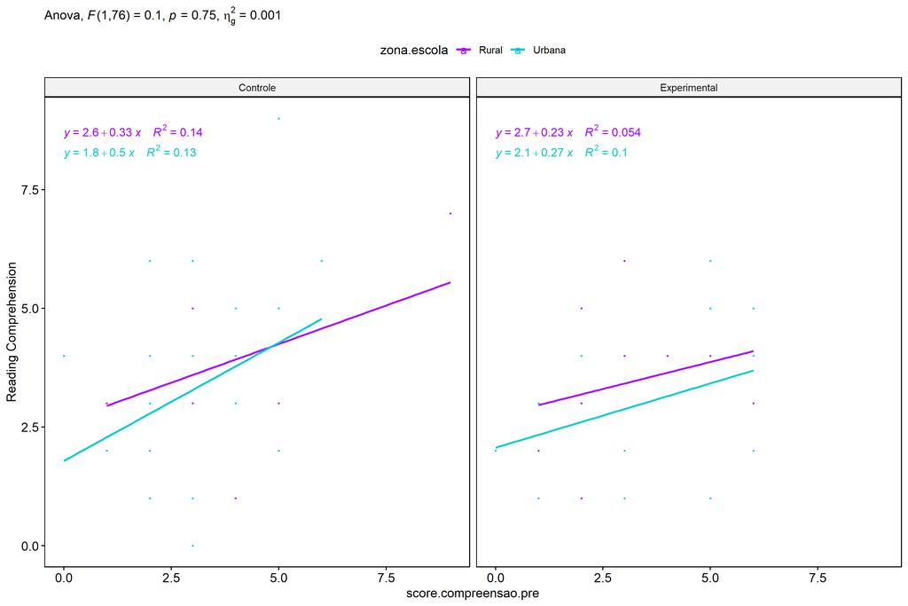

```r
if (length(unique(pdat[["zona.escola"]])) >= 2) {
  ggscatter(wdat, x = "score.compreensao.pre", y = "score.compreensao.pos", size = 0.5,
            color = "zona.escola", facet.by = "grupo", add = "reg.line")+
    stat_regline_equation(
      aes(label =  paste(..eq.label.., ..rr.label.., sep = "~~~~"), color = zona.escola)
    ) +
    ggplot2::labs(subtitle = rstatix::get_test_label(aov, detailed = T, row = which(aov$Effect == "grupo:zona.escola"))) +
    ggplot2::scale_color_manual(values = color[["zona.escola"]]) +
    ggplot2::ylab("Reading Comprehension") +
    if (ymin < ymax) ggplot2::ylim(ymin, ymax)
}
```

### Checking normality and homogeneity

```r
if (length(unique(pdat[["zona.escola"]])) >= 2)
  res <- augment(lm(score.compreensao.pos ~ score.compreensao.pre + grupo*zona.escola, data = wdat))
```

```r
if (length(unique(pdat[["zona.escola"]])) >= 2)
  shapiro_test(res$.resid)
```

```
## # A tibble: 1 × 3
##   variable   statistic p.value
##   <chr>          <dbl>   <dbl>
## 1 res$.resid     0.984   0.398
```

```r
if (length(unique(pdat[["zona.escola"]])) >= 2)
  levene_test(res, .resid ~ grupo*zona.escola)
```

```
## # A tibble: 1 × 4
##     df1   df2 statistic     p
##   <int> <int>     <dbl> <dbl>
## 1     3    77     0.515 0.673
```

# ANCOVA and Pairwise for two factors **grupo:score.compreensao.quintile**

## Without remove non-normal data

```r
pdat = remove_group_data(dat[!is.na(dat[["grupo"]]) & !is.na(dat[["score.compreensao.quintile"]]),],
                         "score.compreensao.pos", c("grupo","score.compreensao.quintile"))
pdat = pdat[pdat[["score.compreensao.quintile"]] %in% do.call(
  intersect, lapply(unique(pdat[["grupo"]]), FUN = function(x) {
    unique(pdat[["score.compreensao.quintile"]][which(pdat[["grupo"]] == x)])
  })),]
pdat[["grupo"]] = factor(pdat[["grupo"]], level[["grupo"]])
pdat[["score.compreensao.quintile"]] = factor(
  pdat[["score.compreensao.quintile"]],
  level[["score.compreensao.quintile"]][level[["score.compreensao.quintile"]] %in% unique(pdat[["score.compreensao.quintile"]])])

pdat.long <- rbind(pdat[,c("id","grupo","score.compreensao.quintile")], pdat[,c("id","grupo","score.compreensao.quintile")])
pdat.long[["time"]] <- c(rep("pre", nrow(pdat)), rep("pos", nrow(pdat)))
pdat.long[["time"]] <- factor(pdat.long[["time"]], c("pre","pos"))
pdat.long[["score.compreensao"]] <- c(pdat[["score.compreensao.pre"]], pdat[["score.compreensao.pos"]])

if (length(unique(pdat[["score.compreensao.quintile"]])) >= 2) {
  aov = anova_test(pdat, score.compreensao.pos ~ score.compreensao.pre + grupo*score.compreensao.quintile)
  laov[["grupo:score.compreensao.quintile"]] <- get_anova_table(aov)
}
```

```r
if (length(unique(pdat[["score.compreensao.quintile"]])) >= 2) {
  pwcs <- list()
  pwcs[["score.compreensao.quintile"]] <- emmeans_test(
    group_by(pdat, grupo), score.compreensao.pos ~ score.compreensao.quintile,
    covariate = score.compreensao.pre, p.adjust.method = "bonferroni")
  pwcs[["grupo"]] <- emmeans_test(
    group_by(pdat, score.compreensao.quintile), score.compreensao.pos ~ grupo,
    covariate = score.compreensao.pre, p.adjust.method = "bonferroni")

  pwc <- plyr::rbind.fill(pwcs[["grupo"]], pwcs[["score.compreensao.quintile"]])
  pwc <- pwc[,c("grupo","score.compreensao.quintile", colnames(pwc)[!colnames(pwc) %in% c("grupo","score.compreensao.quintile")])]
}
```

```r
if (length(unique(pdat[["score.compreensao.quintile"]])) >= 2) {
  pwc.long <- emmeans_test(dplyr::group_by_at(pdat.long, c("grupo","score.compreensao.quintile")),
                           score.compreensao ~ time,
                           p.adjust.method = "bonferroni")
  lpwc[["grupo:score.compreensao.quintile"]] <- plyr::rbind.fill(pwc, pwc.long)
}
```

```r
if (length(unique(pdat[["score.compreensao.quintile"]])) >= 2) {
  ds <- get.descriptives(pdat, "score.compreensao.pos", c("grupo","score.compreensao.quintile"), covar = "score.compreensao.pre")
  ds <- merge(ds[ds$variable != "score.compreensao.pre",],
              ds[ds$variable == "score.compreensao.pre", !colnames(ds) %in% c("variable")],
              by = c("grupo","score.compreensao.quintile"), all.x = T, suffixes = c("", ".score.compreensao.pre"))
  ds <- merge(get_emmeans(pwcs[["grupo"]]), ds,
              by = c("grupo","score.compreensao.quintile"), suffixes = c(".emms", ""))
  ds <- ds[,c("grupo","score.compreensao.quintile","n","mean.score.compreensao.pre","se.score.compreensao.pre","mean","se",
              "emmean","se.emms","conf.low","conf.high")]

  colnames(ds) <- c("grupo","score.compreensao.quintile", "N", paste0(c("M","SE")," (pre)"),
                    paste0(c("M","SE"), " (unadj)"),
                    paste0(c("M", "SE"), " (adj)"), "conf.low", "conf.high")

  lemms[["grupo:score.compreensao.quintile"]] <- ds
}
```

## Computing ANCOVA and PairWise After removing non-normal data (OK)

```r
if (length(unique(pdat[["score.compreensao.quintile"]])) >= 2) {
  wdat = pdat

  res = residuals(lm(score.compreensao.pos ~ score.compreensao.pre + grupo*score.compreensao.quintile, data = wdat))
  non.normal = getNonNormal(res, wdat$id, plimit = 0.05)

  wdat = wdat[!wdat$id %in% non.normal,]

  wdat.long <- rbind(wdat[,c("id","grupo","score.compreensao.quintile")], wdat[,c("id","grupo","score.compreensao.quintile")])
  wdat.long[["time"]] <- c(rep("pre", nrow(wdat)), rep("pos", nrow(wdat)))
  wdat.long[["time"]] <- factor(wdat.long[["time"]], c("pre","pos"))
  wdat.long[["score.compreensao"]] <- c(wdat[["score.compreensao.pre"]], wdat[["score.compreensao.pos"]])


  ldat[["grupo:score.compreensao.quintile"]] = wdat

  (non.normal)
}
```

```
## [1] "P270"
```

```r
if (length(unique(pdat[["score.compreensao.quintile"]])) >= 2) {
  aov = anova_test(wdat, score.compreensao.pos ~ score.compreensao.pre + grupo*score.compreensao.quintile)
  laov[["grupo:score.compreensao.quintile"]] <- merge(get_anova_table(aov), laov[["grupo:score.compreensao.quintile"]],
                                         by="Effect", suffixes = c("","'"))
  df = get_anova_table(aov)
}
```

| Effect | DFn | DFd | F | p | p<.05 | ges |
| --- | --- | --- | --- | --- | --- | --- |
| score.compreensao.pre | 1 | 66 | 0.197 | 0.658 |  | 0.003 |
| grupo | 1 | 66 | 0.173 | 0.679 |  | 0.003 |
| score.compreensao.quintile | 1 | 66 | 0.412 | 0.523 |  | 0.006 |
| grupo:score.compreensao.quintile | 1 | 66 | 0.045 | 0.833 |  | 0.001 |

```r
if (length(unique(pdat[["score.compreensao.quintile"]])) >= 2) {
  pwcs <- list()
  pwcs[["score.compreensao.quintile"]] <- emmeans_test(
    group_by(wdat, grupo), score.compreensao.pos ~ score.compreensao.quintile,
    covariate = score.compreensao.pre, p.adjust.method = "bonferroni")
  pwcs[["grupo"]] <- emmeans_test(
    group_by(wdat, score.compreensao.quintile), score.compreensao.pos ~ grupo,
    covariate = score.compreensao.pre, p.adjust.method = "bonferroni")

  pwc <- plyr::rbind.fill(pwcs[["grupo"]], pwcs[["score.compreensao.quintile"]])
  pwc <- pwc[,c("grupo","score.compreensao.quintile", colnames(pwc)[!colnames(pwc) %in% c("grupo","score.compreensao.quintile")])]
}
```

| grupo | score.compreensao.quintile | term | .y. | group1 | group2 | df | statistic | p | p.adj | p.adj.signif |
| --- | --- | --- | --- | --- | --- | --- | --- | --- | --- | --- |
|  | 2nd quintile | score.compreensao.pre*grupo | score.compreensao.pos | Controle | Experimental | 66 | 0.210 | 0.834 | 0.834 | ns |
|  | 3rd quintile | score.compreensao.pre*grupo | score.compreensao.pos | Controle | Experimental | 66 | 0.406 | 0.686 | 0.686 | ns |
| Controle |  | score.compreensao.pre*score.compreensao.quintile | score.compreensao.pos | 2nd quintile | 3rd quintile | 66 | -0.647 | 0.520 | 0.520 | ns |
| Experimental |  | score.compreensao.pre*score.compreensao.quintile | score.compreensao.pos | 2nd quintile | 3rd quintile | 66 | -0.292 | 0.771 | 0.771 | ns |

```r
if (length(unique(pdat[["score.compreensao.quintile"]])) >= 2) {
  pwc.long <- emmeans_test(dplyr::group_by_at(wdat.long, c("grupo","score.compreensao.quintile")),
                           score.compreensao ~ time,
                           p.adjust.method = "bonferroni")
  lpwc[["grupo:score.compreensao.quintile"]] <- merge(plyr::rbind.fill(pwc, pwc.long),
                                         lpwc[["grupo:score.compreensao.quintile"]],
                                         by=c("grupo","score.compreensao.quintile","term",".y.","group1","group2"),
                                         suffixes = c("","'"))
}
```

| grupo | score.compreensao.quintile | term | .y. | group1 | group2 | df | statistic | p | p.adj | p.adj.signif |
| --- | --- | --- | --- | --- | --- | --- | --- | --- | --- | --- |
| Controle | 2nd quintile | time | score.compreensao | pre | pos | 134 | -1.320 | 0.189 | 0.189 | ns |
| Controle | 3rd quintile | time | score.compreensao | pre | pos | 134 | 1.356 | 0.177 | 0.177 | ns |
| Experimental | 2nd quintile | time | score.compreensao | pre | pos | 134 | -1.381 | 0.170 | 0.170 | ns |
| Experimental | 3rd quintile | time | score.compreensao | pre | pos | 134 | 2.685 | 0.008 | 0.008 | ** |

```r
if (length(unique(pdat[["score.compreensao.quintile"]])) >= 2) {
  ds <- get.descriptives(wdat, "score.compreensao.pos", c("grupo","score.compreensao.quintile"), covar = "score.compreensao.pre")
  ds <- merge(ds[ds$variable != "score.compreensao.pre",],
              ds[ds$variable == "score.compreensao.pre", !colnames(ds) %in% c("variable")],
              by = c("grupo","score.compreensao.quintile"), all.x = T, suffixes = c("", ".score.compreensao.pre"))
  ds <- merge(get_emmeans(pwcs[["grupo"]]), ds,
              by = c("grupo","score.compreensao.quintile"), suffixes = c(".emms", ""))
  ds <- ds[,c("grupo","score.compreensao.quintile","n","mean.score.compreensao.pre","se.score.compreensao.pre",
              "mean","se","emmean","se.emms","conf.low","conf.high")]

  colnames(ds) <- c("grupo","score.compreensao.quintile", "N", paste0(c("M","SE")," (pre)"),
                    paste0(c("M","SE"), " (unadj)"),
                    paste0(c("M", "SE"), " (adj)"), "conf.low", "conf.high")

  lemms[["grupo:score.compreensao.quintile"]] <- merge(ds, lemms[["grupo:score.compreensao.quintile"]],
                                          by=c("grupo","score.compreensao.quintile"), suffixes = c("","'"))
}
```

| grupo | score.compreensao.quintile | N | M (pre) | SE (pre) | M (unadj) | SE (unadj) | M (adj) | SE (adj) | conf.low | conf.high |
| --- | --- | --- | --- | --- | --- | --- | --- | --- | --- | --- |
| Controle | 2nd quintile | 23 | 2.609 | 0.104 | 3.087 | 0.350 | 3.210 | 0.443 | 2.326 | 4.095 |
| Controle | 3rd quintile | 18 | 4.500 | 0.146 | 3.944 | 0.431 | 3.765 | 0.561 | 2.645 | 4.885 |
| Experimental | 2nd quintile | 21 | 2.429 | 0.111 | 2.952 | 0.320 | 3.105 | 0.498 | 2.111 | 4.099 |
| Experimental | 3rd quintile | 9 | 5.333 | 0.236 | 3.778 | 0.521 | 3.465 | 0.894 | 1.681 | 5.250 |

### Plots for ancova

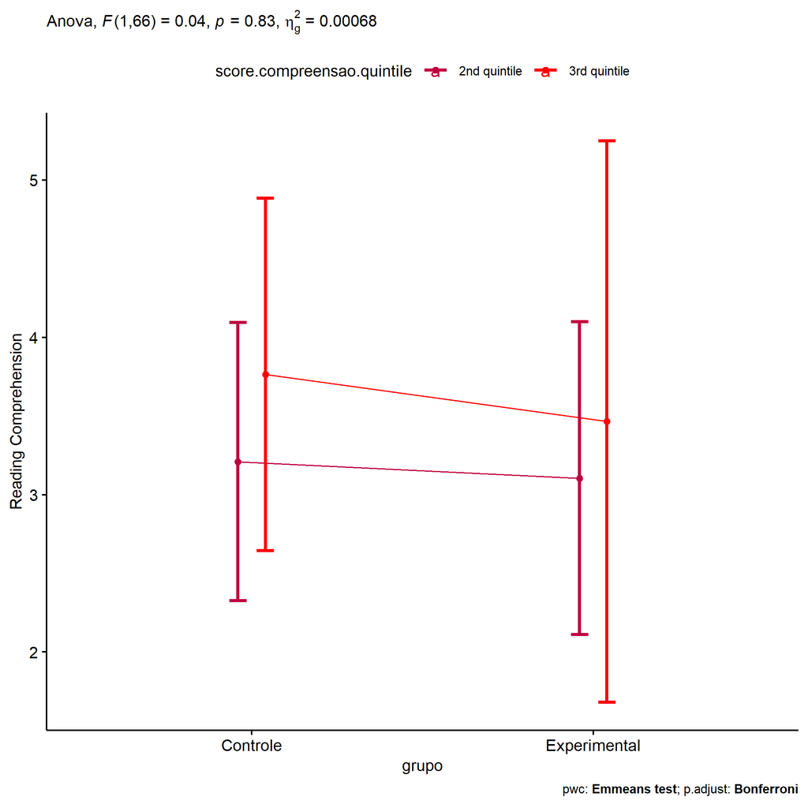

```r
if (length(unique(pdat[["score.compreensao.quintile"]])) >= 2) {
  ggPlotAoC2(pwcs, "grupo", "score.compreensao.quintile", aov, ylab = "Reading Comprehension",
             subtitle = which(aov$Effect == "grupo:score.compreensao.quintile"), addParam = "errorbar") +
    ggplot2::scale_color_manual(values = color[["score.compreensao.quintile"]]) +
    ggplot2::ylab("Reading Comprehension") +
    if (ymin.ci < ymax.ci) ggplot2::ylim(ymin.ci, ymax.ci)
}
```

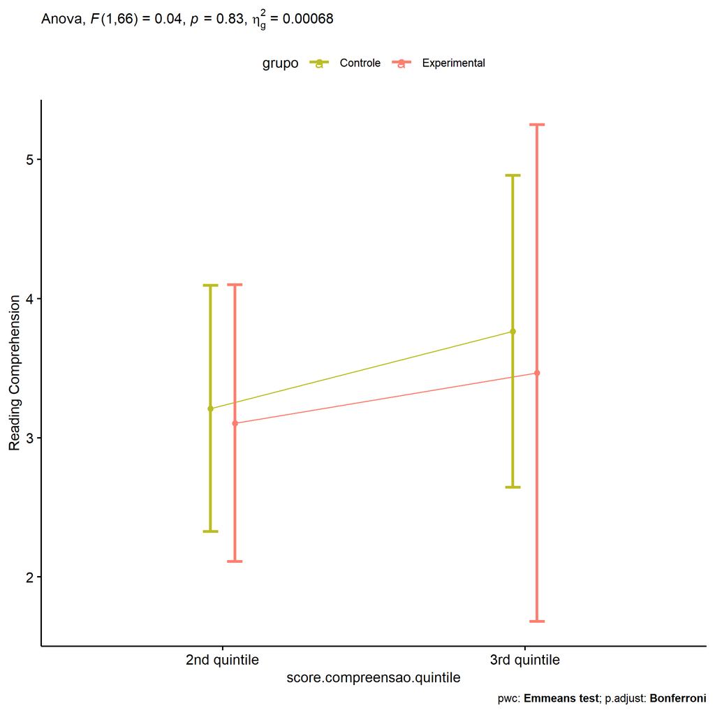

```r
if (length(unique(pdat[["score.compreensao.quintile"]])) >= 2) {
  ggPlotAoC2(pwcs, "score.compreensao.quintile", "grupo", aov, ylab = "Reading Comprehension",
               subtitle = which(aov$Effect == "grupo:score.compreensao.quintile"), addParam = "errorbar") +
    ggplot2::scale_color_manual(values = color[["grupo"]]) +
    ggplot2::ylab("Reading Comprehension") +
    if (ymin.ci < ymax.ci) ggplot2::ylim(ymin.ci, ymax.ci)
}
```

```r
if (length(unique(pdat[["score.compreensao.quintile"]])) >= 2) {
  plots <- twoWayAncovaBoxPlots(
    wdat, "score.compreensao.pos", c("grupo","score.compreensao.quintile"), aov, pwcs, covar = "score.compreensao.pre",
    theme = "classic", color = color[["grupo:score.compreensao.quintile"]],
    subtitle = which(aov$Effect == "grupo:score.compreensao.quintile"))
}
```

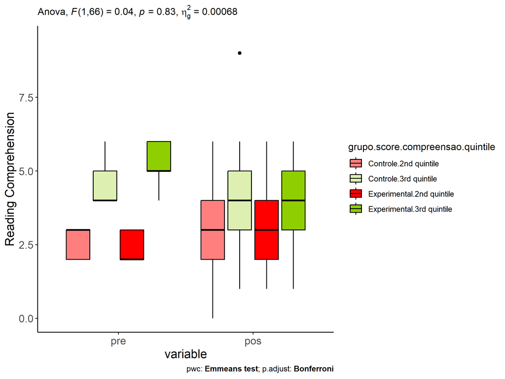

```r
if (length(unique(pdat[["score.compreensao.quintile"]])) >= 2) {
  plots[["grupo:score.compreensao.quintile"]] + ggplot2::ylab("Reading Comprehension") +
  ggplot2::scale_x_discrete(labels=c('pre', 'pos')) +
  if (ymin < ymax) ggplot2::ylim(ymin, ymax)
}
```

```r
if (length(unique(pdat[["score.compreensao.quintile"]])) >= 2) {
  plots <- twoWayAncovaBoxPlots(
    wdat.long, "score.compreensao", c("grupo","score.compreensao.quintile"), aov, pwc.long,
    pre.post = "time",
    theme = "classic", color = color$prepost)
}
```

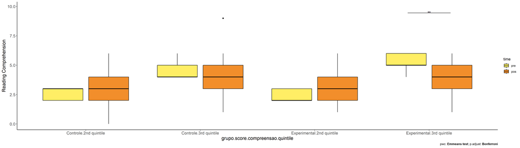

```r
if (length(unique(pdat[["score.compreensao.quintile"]])) >= 2)
  plots[["grupo:score.compreensao.quintile"]] + ggplot2::ylab("Reading Comprehension") +
    if (ymin < ymax) ggplot2::ylim(ymin, ymax)
```

### Checking linearity assumption

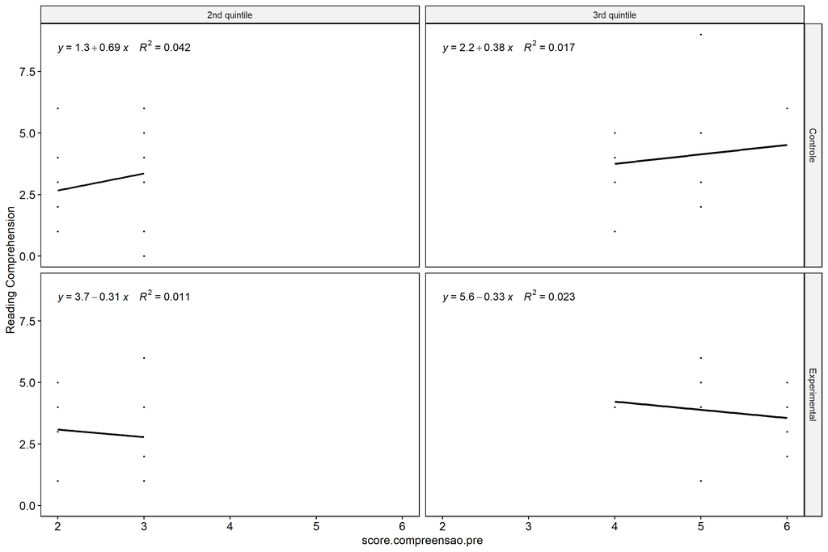

```r
if (length(unique(pdat[["score.compreensao.quintile"]])) >= 2) {
  ggscatter(wdat, x = "score.compreensao.pre", y = "score.compreensao.pos", size = 0.5,
            facet.by = c("grupo","score.compreensao.quintile"), add = "reg.line")+
    stat_regline_equation(
      aes(label =  paste(..eq.label.., ..rr.label.., sep = "~~~~"))
    ) + ggplot2::ylab("Reading Comprehension") +
    if (ymin < ymax) ggplot2::ylim(ymin, ymax)
}
```

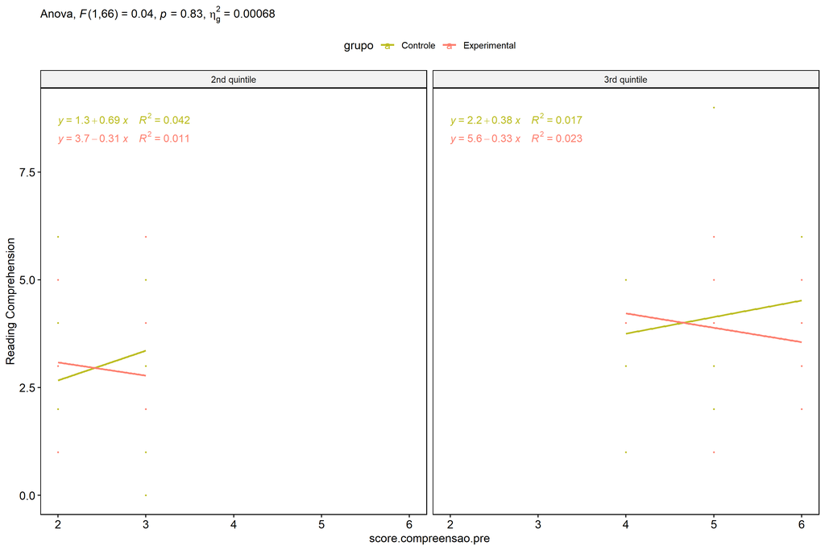

```r
if (length(unique(pdat[["score.compreensao.quintile"]])) >= 2) {
  ggscatter(wdat, x = "score.compreensao.pre", y = "score.compreensao.pos", size = 0.5,
            color = "grupo", facet.by = "score.compreensao.quintile", add = "reg.line")+
    stat_regline_equation(
      aes(label =  paste(..eq.label.., ..rr.label.., sep = "~~~~"), color = grupo)
    ) +
    ggplot2::labs(subtitle = rstatix::get_test_label(aov, detailed = T, row = which(aov$Effect == "grupo:score.compreensao.quintile"))) +
    ggplot2::scale_color_manual(values = color[["grupo"]]) +
    ggplot2::ylab("Reading Comprehension") +
    if (ymin < ymax) ggplot2::ylim(ymin, ymax)
}
```

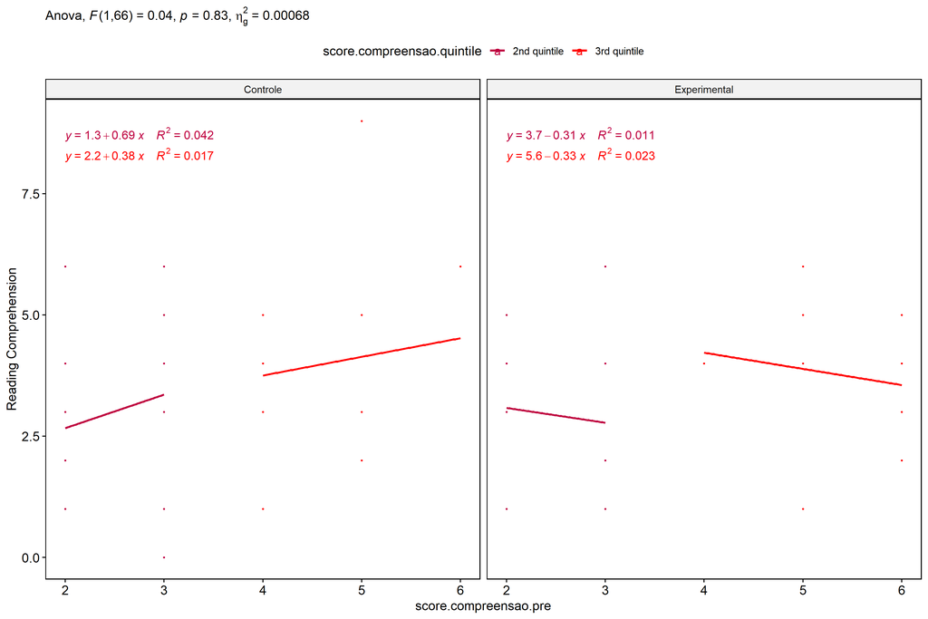

```r
if (length(unique(pdat[["score.compreensao.quintile"]])) >= 2) {
  ggscatter(wdat, x = "score.compreensao.pre", y = "score.compreensao.pos", size = 0.5,
            color = "score.compreensao.quintile", facet.by = "grupo", add = "reg.line")+
    stat_regline_equation(
      aes(label =  paste(..eq.label.., ..rr.label.., sep = "~~~~"), color = score.compreensao.quintile)
    ) +
    ggplot2::labs(subtitle = rstatix::get_test_label(aov, detailed = T, row = which(aov$Effect == "grupo:score.compreensao.quintile"))) +
    ggplot2::scale_color_manual(values = color[["score.compreensao.quintile"]]) +
    ggplot2::ylab("Reading Comprehension") +
    if (ymin < ymax) ggplot2::ylim(ymin, ymax)
}
```

### Checking normality and homogeneity

```r
if (length(unique(pdat[["score.compreensao.quintile"]])) >= 2)
  res <- augment(lm(score.compreensao.pos ~ score.compreensao.pre + grupo*score.compreensao.quintile, data = wdat))
```

```r
if (length(unique(pdat[["score.compreensao.quintile"]])) >= 2)
  shapiro_test(res$.resid)
```

```
## # A tibble: 1 × 3
##   variable   statistic p.value
##   <chr>          <dbl>   <dbl>
## 1 res$.resid     0.968  0.0702
```

```r
if (length(unique(pdat[["score.compreensao.quintile"]])) >= 2)
  levene_test(res, .resid ~ grupo*score.compreensao.quintile)
```

```
## # A tibble: 1 × 4
##     df1   df2 statistic     p
##   <int> <int>     <dbl> <dbl>
## 1     3    67     0.141 0.935
```

# Summary of Results

## Descriptive Statistics

```r
df <- get.descriptives(ldat[["grupo"]], c(dv.pre, dv.pos), c("grupo"),
                       include.global = T, symmetry.test = T, normality.test = F)
df <- plyr::rbind.fill(
  df, do.call(plyr::rbind.fill, lapply(lfatores2, FUN = function(f) {
    if (nrow(dat) > 0 && sum(!is.na(unique(dat[[f]]))) > 1 && paste0("grupo:",f) %in% names(ldat))
      get.descriptives(ldat[[paste0("grupo:",f)]], c(dv.pre,dv.pos), c("grupo", f),
                       symmetry.test = T, normality.test = F)
    }))
)
df <- df[,c(fatores1[fatores1 %in% colnames(df)],"variable",
             colnames(df)[!colnames(df) %in% c(fatores1,"variable")])]
```

| grupo | genero | zona.participante | zona.escola | score.compreensao.quintile | variable | n | mean | median | min | max | sd | se | ci | iqr | symmetry | skewness | kurtosis |
| --- | --- | --- | --- | --- | --- | --- | --- | --- | --- | --- | --- | --- | --- | --- | --- | --- | --- |
| Controle |  |  |  |  | score.compreensao.pre | 45 | 3.378 | 3.0 | 0 | 9 | 1.527 | 0.228 | 0.459 | 2.00 | NO | 0.864 | 2.410 |
| Experimental |  |  |  |  | score.compreensao.pre | 36 | 2.889 | 2.5 | 0 | 6 | 1.635 | 0.272 | 0.553 | 1.25 | NO | 0.593 | -0.681 |
|  |  |  |  |  | score.compreensao.pre | 81 | 3.160 | 3.0 | 0 | 9 | 1.585 | 0.176 | 0.350 | 2.00 | NO | 0.688 | 0.933 |
| Controle |  |  |  |  | score.compreensao.pos | 45 | 3.511 | 3.0 | 0 | 9 | 1.792 | 0.267 | 0.538 | 2.00 | NO | 0.573 | 0.436 |
| Experimental |  |  |  |  | score.compreensao.pos | 36 | 3.028 | 3.0 | 1 | 6 | 1.464 | 0.244 | 0.495 | 2.00 | YES | 0.219 | -0.894 |
|  |  |  |  |  | score.compreensao.pos | 81 | 3.296 | 3.0 | 0 | 9 | 1.662 | 0.185 | 0.367 | 2.00 | NO | 0.548 | 0.423 |
| Controle | F |  |  |  | score.compreensao.pre | 24 | 3.458 | 3.0 | 0 | 9 | 1.744 | 0.356 | 0.736 | 1.25 | NO | 0.915 | 2.243 |
| Controle | M |  |  |  | score.compreensao.pre | 21 | 3.286 | 3.0 | 1 | 6 | 1.271 | 0.277 | 0.578 | 2.00 | YES | 0.321 | -0.766 |
| Experimental | F |  |  |  | score.compreensao.pre | 17 | 2.882 | 2.0 | 1 | 6 | 1.576 | 0.382 | 0.811 | 1.00 | NO | 0.992 | -0.640 |
| Experimental | M |  |  |  | score.compreensao.pre | 19 | 2.895 | 3.0 | 0 | 6 | 1.729 | 0.397 | 0.833 | 2.00 | YES | 0.275 | -0.938 |
| Controle | F |  |  |  | score.compreensao.pos | 24 | 4.208 | 4.0 | 2 | 9 | 1.793 | 0.366 | 0.757 | 2.00 | NO | 0.654 | 0.015 |
| Controle | M |  |  |  | score.compreensao.pos | 21 | 2.714 | 3.0 | 0 | 6 | 1.454 | 0.317 | 0.662 | 2.00 | YES | 0.104 | -0.626 |
| Experimental | F |  |  |  | score.compreensao.pos | 17 | 3.353 | 3.0 | 1 | 6 | 1.222 | 0.296 | 0.628 | 1.00 | YES | 0.321 | -0.312 |
| Experimental | M |  |  |  | score.compreensao.pos | 19 | 2.737 | 2.0 | 1 | 6 | 1.628 | 0.373 | 0.784 | 3.00 | YES | 0.403 | -1.261 |
| Controle |  | Rural |  |  | score.compreensao.pre | 12 | 3.417 | 3.5 | 2 | 5 | 0.900 | 0.260 | 0.572 | 1.00 | YES | -0.116 | -1.093 |
| Controle |  | Urbana |  |  | score.compreensao.pre | 23 | 3.696 | 3.0 | 1 | 9 | 1.743 | 0.364 | 0.754 | 2.50 | NO | 1.040 | 1.376 |
| Experimental |  | Rural |  |  | score.compreensao.pre | 14 | 3.357 | 3.0 | 1 | 6 | 1.865 | 0.498 | 1.077 | 3.00 | YES | 0.307 | -1.605 |
| Experimental |  | Urbana |  |  | score.compreensao.pre | 12 | 2.167 | 2.0 | 0 | 6 | 1.467 | 0.423 | 0.932 | 0.50 | NO | 1.165 | 1.368 |
| Controle |  | Rural |  |  | score.compreensao.pos | 12 | 3.667 | 4.0 | 2 | 5 | 0.985 | 0.284 | 0.626 | 1.00 | YES | -0.427 | -1.031 |
| Controle |  | Urbana |  |  | score.compreensao.pos | 23 | 4.000 | 4.0 | 1 | 9 | 2.067 | 0.431 | 0.894 | 3.50 | YES | 0.443 | -0.576 |
| Experimental |  | Rural |  |  | score.compreensao.pos | 14 | 3.143 | 3.0 | 1 | 6 | 1.351 | 0.361 | 0.780 | 2.00 | YES | 0.458 | -0.680 |
| Experimental |  | Urbana |  |  | score.compreensao.pos | 12 | 2.917 | 3.0 | 1 | 5 | 1.443 | 0.417 | 0.917 | 2.25 | YES | -0.035 | -1.433 |
| Controle |  |  | Rural |  | score.compreensao.pre | 13 | 4.000 | 4.0 | 1 | 9 | 1.826 | 0.506 | 1.103 | 1.00 | NO | 1.213 | 1.929 |
| Controle |  |  | Urbana |  | score.compreensao.pre | 32 | 3.125 | 3.0 | 0 | 6 | 1.338 | 0.237 | 0.482 | 2.00 | YES | 0.093 | -0.434 |
| Experimental |  |  | Rural |  | score.compreensao.pre | 12 | 3.000 | 3.0 | 1 | 6 | 1.414 | 0.408 | 0.899 | 1.25 | NO | 0.707 | -0.542 |
| Experimental |  |  | Urbana |  | score.compreensao.pre | 24 | 2.833 | 2.0 | 0 | 6 | 1.761 | 0.359 | 0.744 | 1.50 | NO | 0.563 | -0.915 |
| Controle |  |  | Rural |  | score.compreensao.pos | 13 | 3.923 | 4.0 | 1 | 7 | 1.605 | 0.445 | 0.970 | 2.00 | YES | 0.114 | -0.686 |
| Controle |  |  | Urbana |  | score.compreensao.pos | 32 | 3.344 | 3.0 | 0 | 9 | 1.860 | 0.329 | 0.671 | 2.00 | NO | 0.763 | 0.758 |
| Experimental |  |  | Rural |  | score.compreensao.pos | 12 | 3.417 | 3.5 | 1 | 6 | 1.379 | 0.398 | 0.876 | 1.25 | YES | 0.063 | -0.844 |
| Experimental |  |  | Urbana |  | score.compreensao.pos | 24 | 2.833 | 3.0 | 1 | 6 | 1.494 | 0.305 | 0.631 | 2.25 | YES | 0.347 | -0.976 |
| Controle |  |  |  | 2nd quintile | score.compreensao.pre | 23 | 2.609 | 3.0 | 2 | 3 | 0.499 | 0.104 | 0.216 | 1.00 | few data | 0.000 | 0.000 |
| Controle |  |  |  | 3rd quintile | score.compreensao.pre | 18 | 4.500 | 4.0 | 4 | 6 | 0.618 | 0.146 | 0.307 | 1.00 | few data | 0.000 | 0.000 |
| Experimental |  |  |  | 2nd quintile | score.compreensao.pre | 21 | 2.429 | 2.0 | 2 | 3 | 0.507 | 0.111 | 0.231 | 1.00 | few data | 0.000 | 0.000 |
| Experimental |  |  |  | 3rd quintile | score.compreensao.pre | 9 | 5.333 | 5.0 | 4 | 6 | 0.707 | 0.236 | 0.544 | 1.00 | few data | 0.000 | 0.000 |
| Controle |  |  |  | 2nd quintile | score.compreensao.pos | 23 | 3.087 | 3.0 | 0 | 6 | 1.676 | 0.350 | 0.725 | 2.00 | YES | 0.202 | -0.866 |
| Controle |  |  |  | 3rd quintile | score.compreensao.pos | 18 | 3.944 | 4.0 | 1 | 9 | 1.830 | 0.431 | 0.910 | 2.00 | NO | 0.838 | 0.944 |
| Experimental |  |  |  | 2nd quintile | score.compreensao.pos | 21 | 2.952 | 3.0 | 1 | 6 | 1.465 | 0.320 | 0.667 | 2.00 | YES | 0.169 | -0.930 |
| Experimental |  |  |  | 3rd quintile | score.compreensao.pos | 9 | 3.778 | 4.0 | 1 | 6 | 1.563 | 0.521 | 1.202 | 2.00 | YES | -0.374 | -1.164 |

## ANCOVA Table Comparison

```r
df <- do.call(plyr::rbind.fill, laov)
df <- df[!duplicated(df$Effect),]
```

|  | Effect | DFn | DFd | F | p | p<.05 | ges | DFn’ | DFd’ | F’ | p’ | p<.05’ | ges’ |
| --- | --- | --- | --- | --- | --- | --- | --- | --- | --- | --- | --- | --- | --- |
| 1 | grupo | 1 | 78 | 0.756 | 0.387 |  | 0.010 | 1 | 79 | 0.157 | 0.693 |  | 0.002 |
| 2 | score.compreensao.pre | 1 | 78 | 10.330 | 0.002 | * | 0.117 | 1 | 79 | 7.451 | 0.008 | * | 0.086 |
| 3 | genero | 1 | 76 | 10.703 | 0.002 | * | 0.123 | 1 | 77 | 11.788 | 0.001 | * | 0.133 |
| 5 | grupo:genero | 1 | 76 | 1.524 | 0.221 |  | 0.020 | 1 | 77 | 0.471 | 0.494 |  | 0.006 |
| 8 | grupo:zona.participante | 1 | 56 | 0.001 | 0.970 |  | 0.000 | 1 | 57 | 0.265 | 0.609 |  | 0.005 |
| 10 | zona.participante | 1 | 56 | 0.341 | 0.561 |  | 0.006 | 1 | 57 | 0.003 | 0.955 |  | 0.000 |
| 12 | grupo:zona.escola | 1 | 76 | 0.105 | 0.747 |  | 0.001 | 1 | 77 | 0.001 | 0.972 |  | 0.000 |
| 14 | zona.escola | 1 | 76 | 1.061 | 0.306 |  | 0.014 | 1 | 77 | 0.474 | 0.493 |  | 0.006 |
| 16 | grupo:score.compreensao.quintile | 1 | 66 | 0.045 | 0.833 |  | 0.001 | 1 | 67 | 0.125 | 0.725 |  | 0.002 |
| 18 | score.compreensao.quintile | 1 | 66 | 0.412 | 0.523 |  | 0.006 | 1 | 67 | 0.687 | 0.410 |  | 0.010 |

## PairWise Table Comparison

```r
df <- do.call(plyr::rbind.fill, lpwc)
df <- df[,c(names(lfatores)[names(lfatores) %in% colnames(df)],
            names(df)[!names(df) %in% c(names(lfatores),"term",".y.")])]
```

| grupo | genero | zona.participante | zona.escola | score.compreensao.quintile | group1 | group2 | df | statistic | p | p.adj | p.adj.signif | df’ | statistic’ | p’ | p.adj’ | p.adj.signif’ |
| --- | --- | --- | --- | --- | --- | --- | --- | --- | --- | --- | --- | --- | --- | --- | --- | --- |
| Controle |  |  |  |  | pre | pos | 158 | -0.391 | 0.696 | 0.696 | ns | 160 | -0.378 | 0.706 | 0.706 | ns |
| Experimental |  |  |  |  | pre | pos | 158 | -0.365 | 0.716 | 0.716 | ns | 160 | -0.834 | 0.406 | 0.406 | ns |
|  |  |  |  |  | Controle | Experimental | 78 | 0.869 | 0.387 | 0.387 | ns | 79 | 0.397 | 0.693 | 0.693 | ns |
| Controle | F |  |  |  | pre | pos | 154 | -1.646 | 0.102 | 0.102 | ns | 156 | -1.594 | 0.113 | 0.113 | ns |
| Controle | M |  |  |  | pre | pos | 154 | 1.173 | 0.243 | 0.243 | ns | 156 | 1.136 | 0.258 | 0.258 | ns |
| Controle |  |  |  |  | F | M | 76 | 3.261 | 0.002 | 0.002 | ** | 77 | 3.002 | 0.004 | 0.004 | ** |
| Experimental | F |  |  |  | pre | pos | 154 | -0.869 | 0.386 | 0.386 | ns | 156 | -1.534 | 0.127 | 0.127 | ns |
| Experimental | M |  |  |  | pre | pos | 154 | 0.308 | 0.758 | 0.758 | ns | 156 | 0.299 | 0.766 | 0.766 | ns |
| Experimental |  |  |  |  | F | M | 76 | 1.263 | 0.210 | 0.210 | ns | 77 | 1.801 | 0.076 | 0.076 | ns |
|  | F |  |  |  | Controle | Experimental | 76 | 1.396 | 0.167 | 0.167 | ns | 77 | 0.677 | 0.501 | 0.501 | ns |
|  | M |  |  |  | Controle | Experimental | 76 | -0.337 | 0.737 | 0.737 | ns | 77 | -0.290 | 0.773 | 0.773 | ns |
| Controle |  |  |  |  | Rural | Urbana | 56 | -0.410 | 0.683 | 0.683 | ns | 57 | -0.389 | 0.699 | 0.699 | ns |
| Controle |  | Rural |  |  | pre | pos | 114 | -0.380 | 0.705 | 0.705 | ns | 116 | -0.363 | 0.717 | 0.717 | ns |
| Controle |  | Urbana |  |  | pre | pos | 114 | -0.641 | 0.523 | 0.523 | ns | 116 | -0.612 | 0.542 | 0.542 | ns |
| Experimental |  |  |  |  | Rural | Urbana | 56 | -0.411 | 0.683 | 0.683 | ns | 57 | 0.347 | 0.730 | 0.730 | ns |
| Experimental |  | Rural |  |  | pre | pos | 114 | 0.352 | 0.726 | 0.726 | ns | 116 | -0.433 | 0.666 | 0.666 | ns |
| Experimental |  | Urbana |  |  | pre | pos | 114 | -1.140 | 0.257 | 0.257 | ns | 116 | -1.090 | 0.278 | 0.278 | ns |
|  |  | Rural |  |  | Controle | Experimental | 56 | 0.841 | 0.404 | 0.404 | ns | 57 | 0.123 | 0.902 | 0.902 | ns |
|  |  | Urbana |  |  | Controle | Experimental | 56 | 0.821 | 0.415 | 0.415 | ns | 57 | 0.859 | 0.394 | 0.394 | ns |
| Controle |  |  |  |  | Rural | Urbana | 76 | 0.528 | 0.599 | 0.599 | ns | 77 | 0.524 | 0.602 | 0.602 | ns |
| Controle |  |  | Rural |  | pre | pos | 154 | 0.122 | 0.903 | 0.903 | ns | 156 | 0.117 | 0.907 | 0.907 | ns |
| Controle |  |  | Urbana |  | pre | pos | 154 | -0.543 | 0.588 | 0.588 | ns | 156 | -0.523 | 0.602 | 0.602 | ns |
| Experimental |  |  |  |  | Rural | Urbana | 76 | 0.945 | 0.348 | 0.348 | ns | 77 | 0.452 | 0.653 | 0.653 | ns |
| Experimental |  |  | Rural |  | pre | pos | 154 | -0.634 | 0.527 | 0.527 | ns | 156 | -0.610 | 0.543 | 0.543 | ns |
| Experimental |  |  | Urbana |  | pre | pos | 154 | 0.000 | 1.000 | 1.000 | ns | 156 | -0.592 | 0.555 | 0.555 | ns |
|  |  |  | Rural |  | Controle | Experimental | 76 | 0.254 | 0.800 | 0.800 | ns | 77 | 0.271 | 0.787 | 0.787 | ns |
|  |  |  | Urbana |  | Controle | Experimental | 76 | 0.962 | 0.339 | 0.339 | ns | 77 | 0.349 | 0.728 | 0.728 | ns |
| Controle |  |  |  | 2nd quintile | pre | pos | 134 | -1.320 | 0.189 | 0.189 | ns | 136 | -1.227 | 0.222 | 0.222 | ns |
| Controle |  |  |  | 3rd quintile | pre | pos | 134 | 1.356 | 0.177 | 0.177 | ns | 136 | 1.261 | 0.209 | 0.209 | ns |
| Controle |  |  |  |  | 2nd quintile | 3rd quintile | 66 | -0.647 | 0.520 | 0.520 | ns | 67 | -0.837 | 0.405 | 0.405 | ns |
| Experimental |  |  |  | 2nd quintile | pre | pos | 134 | -1.381 | 0.170 | 0.170 | ns | 136 | -2.054 | 0.042 | 0.042 | * |
| Experimental |  |  |  | 3rd quintile | pre | pos | 134 | 2.685 | 0.008 | 0.008 | ** | 136 | 2.497 | 0.014 | 0.014 | * |
| Experimental |  |  |  |  | 2nd quintile | 3rd quintile | 66 | -0.292 | 0.771 | 0.771 | ns | 67 | -0.318 | 0.752 | 0.752 | ns |
|  |  |  |  | 2nd quintile | Controle | Experimental | 66 | 0.210 | 0.834 | 0.834 | ns | 67 | -0.275 | 0.784 | 0.784 | ns |
|  |  |  |  | 3rd quintile | Controle | Experimental | 66 | 0.406 | 0.686 | 0.686 | ns | 67 | 0.252 | 0.802 | 0.802 | ns |

## EMMS Table Comparison

```r
df <- do.call(plyr::rbind.fill, lemms)
df[["N-N'"]] <- df[["N"]] - df[["N'"]]
df <- df[,c(names(lfatores)[names(lfatores) %in% colnames(df)],
            names(df)[!names(df) %in% names(lfatores)])]
```

| grupo | genero | zona.participante | zona.escola | score.compreensao.quintile | N | M (pre) | SE (pre) | M (unadj) | SE (unadj) | M (adj) | SE (adj) | conf.low | conf.high | N’ | M (pre)’ | SE (pre)’ | M (unadj)’ | SE (unadj)’ | M (adj)’ | SE (adj)’ | conf.low’ | conf.high’ | N-N’ |
| --- | --- | --- | --- | --- | --- | --- | --- | --- | --- | --- | --- | --- | --- | --- | --- | --- | --- | --- | --- | --- | --- | --- | --- |
| Controle |  |  |  |  | 45 | 3.378 | 0.228 | 3.511 | 0.267 | 3.433 | 0.234 | 2.966 | 3.900 | 45 | 3.378 | 0.228 | 3.511 | 0.267 | 3.434 | 0.256 | 2.926 | 3.943 | 0 |
| Experimental |  |  |  |  | 36 | 2.889 | 0.272 | 3.028 | 0.244 | 3.125 | 0.263 | 2.603 | 3.648 | 37 | 2.865 | 0.266 | 3.189 | 0.287 | 3.282 | 0.282 | 2.721 | 3.844 | -1 |
| Controle | F |  |  |  | 24 | 3.458 | 0.356 | 4.208 | 0.366 | 4.105 | 0.302 | 3.504 | 4.707 | 24 | 3.458 | 0.356 | 4.208 | 0.366 | 4.108 | 0.329 | 3.453 | 4.764 | 0 |
| Controle | M |  |  |  | 21 | 3.286 | 0.277 | 2.714 | 0.317 | 2.671 | 0.321 | 2.031 | 3.311 | 21 | 3.286 | 0.277 | 2.714 | 0.317 | 2.670 | 0.350 | 1.973 | 3.367 | 0 |
| Experimental | F |  |  |  | 17 | 2.882 | 0.382 | 3.353 | 0.296 | 3.449 | 0.358 | 2.736 | 4.162 | 18 | 2.833 | 0.364 | 3.667 | 0.420 | 3.767 | 0.379 | 3.011 | 4.522 | -1 |
| Experimental | M |  |  |  | 19 | 2.895 | 0.397 | 2.737 | 0.373 | 2.829 | 0.339 | 2.154 | 3.503 | 19 | 2.895 | 0.397 | 2.737 | 0.373 | 2.817 | 0.369 | 2.083 | 3.552 | 0 |
| Controle |  | Rural |  |  | 12 | 3.417 | 0.260 | 3.667 | 0.284 | 3.605 | 0.437 | 2.730 | 4.480 | 12 | 3.417 | 0.260 | 3.667 | 0.284 | 3.606 | 0.493 | 2.619 | 4.593 | 0 |
| Controle |  | Urbana |  |  | 23 | 3.696 | 0.364 | 4.000 | 0.431 | 3.826 | 0.320 | 3.185 | 4.467 | 23 | 3.696 | 0.364 | 4.000 | 0.431 | 3.843 | 0.361 | 3.119 | 4.566 | 0 |
| Experimental |  | Rural |  |  | 14 | 3.357 | 0.498 | 3.143 | 0.361 | 3.105 | 0.404 | 2.295 | 3.914 | 15 | 3.267 | 0.473 | 3.533 | 0.515 | 3.525 | 0.440 | 2.643 | 4.406 | -1 |
| Experimental |  | Urbana |  |  | 12 | 2.167 | 0.423 | 2.917 | 0.417 | 3.357 | 0.458 | 2.440 | 4.273 | 12 | 2.167 | 0.423 | 2.917 | 0.417 | 3.289 | 0.515 | 2.258 | 4.321 | 0 |
| Controle |  |  | Rural |  | 13 | 4.000 | 0.506 | 3.923 | 0.445 | 3.634 | 0.447 | 2.745 | 4.524 | 13 | 4.000 | 0.506 | 3.923 | 0.445 | 3.653 | 0.489 | 2.679 | 4.626 | 0 |
| Controle |  |  | Urbana |  | 32 | 3.125 | 0.237 | 3.344 | 0.329 | 3.356 | 0.278 | 2.802 | 3.910 | 32 | 3.125 | 0.237 | 3.344 | 0.329 | 3.351 | 0.304 | 2.745 | 3.956 | 0 |
| Experimental |  |  | Rural |  | 12 | 3.000 | 0.408 | 3.417 | 0.398 | 3.472 | 0.454 | 2.567 | 4.377 | 12 | 3.000 | 0.408 | 3.417 | 0.398 | 3.463 | 0.497 | 2.473 | 4.453 | 0 |
| Experimental |  |  | Urbana |  | 24 | 2.833 | 0.359 | 2.833 | 0.305 | 2.946 | 0.323 | 2.302 | 3.590 | 25 | 2.800 | 0.346 | 3.080 | 0.383 | 3.190 | 0.347 | 2.499 | 3.880 | -1 |
| Controle |  |  |  | 2nd quintile | 23 | 2.609 | 0.104 | 3.087 | 0.350 | 3.210 | 0.443 | 2.326 | 4.095 | 23 | 2.609 | 0.104 | 3.087 | 0.350 | 3.119 | 0.475 | 2.170 | 4.068 | 0 |
| Controle |  |  |  | 3rd quintile | 18 | 4.500 | 0.146 | 3.944 | 0.431 | 3.765 | 0.561 | 2.645 | 4.885 | 18 | 4.500 | 0.146 | 3.944 | 0.431 | 3.896 | 0.613 | 2.673 | 5.120 | 0 |
| Experimental |  |  |  | 2nd quintile | 21 | 2.429 | 0.111 | 2.952 | 0.320 | 3.105 | 0.498 | 2.111 | 4.099 | 22 | 2.409 | 0.107 | 3.227 | 0.411 | 3.268 | 0.533 | 2.204 | 4.331 | -1 |
| Experimental |  |  |  | 3rd quintile | 9 | 5.333 | 0.236 | 3.778 | 0.521 | 3.465 | 0.894 | 1.681 | 5.250 | 9 | 5.333 | 0.236 | 3.778 | 0.521 | 3.694 | 0.973 | 1.751 | 5.637 | 0 |